# Smoothing models

## Get data

```r
library(mgcv); library(data.table); library(gratia); library(marginaleffects); library(ggplot2); library(dplyr); library(tidyr); library(zoo); library(slider); library(here);library(broom); library(readr);library(lme4); library(ggfortify); library(forcats); library(patchwork); library(performance)




data=read_tsv("G:/My Drive/cesab bioforest/Data/data.tsv")

sites=c("Corinto" ,"Jari" , "Lesong" ,"Mbaiki","Misiones", "Paracou",
"SUAS" ,"Sungai Lalang", "Ulu Muda")

setDT(data)

setnames(data, "plot", "subplot")

data[, plot := gsub("_.*$", "", subplot)]


load("../clim_by_site_total.rda")


plots_df <- do.call(rbind, lapply(names(clim_by_site), function(site_name) {
  data.frame(
    site = site_name,
    plot = unlist(lapply(clim_by_site[[site_name]], function(block) block$plot)),
    stringsAsFactors = FALSE
  )
}))

census_anom_all_sites<- list()

all_sites_results <- list()

clim_site_results <- list()

for (s in sites) {

  cat("Processing", s, "\n")

  ## ---- subset obs

  obs_site <- data[site == s]

  #obs_site2=obs_site[!duplicated(obs_site)]

  obs_site2 <- obs_site[rel_year >= 0]


  obs_site_wide <- dcast(
  obs_site2,
  treatment+site + subplot + plot+ year ~ variable,
  value.var = "value"
)


  ## ---- climate stack
  clim_all <- rbindlist(
    lapply(clim_by_site[[s]], function(x) x$climate[[1]]),
    idcol = "plot"
  )


  clim_all[, tmean := (tmax + tmin) / 2]

  clim_all[, cwd := NA_real_]#pre-allocated

  clim_all[
  , wmy := month[which.max(ppt)],
  by = year]#wettest month per year


#function compute CWD

fcwd_et <- function(cwd, ppt, aet, wmy, month, min_aet = 40, throughfall = 1,
                    reset_wmy = TRUE, min_cwd = -1000) {
  # ppt: monthly precipitation
  # eat: evapotranspiration (actual or climatological)
  # wmy: wettest month of the year
  # min_et: minimum ET threshold to avoid unrealistically low ET
  # throughfall: fraction of ppt that contributes to water balance
  # reset_wmy: logical, reset CWD at wettest month
  # min_cwd: lower bound for cumulative deficit


  for (i in seq(2, length(ppt))) {           # loop from month 2 to end
    # accumulate CWD: previous month's deficit + current month's water balance
    cwd[i] <- min(0, cwd[i-1] + (throughfall*ppt[i]) - max(aet[i], min_aet, na.rm = T), na.rm = T)

    # reset CWD to zero if this is the wettest month
    if (reset_wmy==T) {
      cwd[i] <- ifelse(month[i] == wmy[i], 0, cwd[i])
    }

    # impose lower bound: deficit cannot exceed min_cwd
   cwd[i] <- ifelse(cwd[i] < -1000, -1000, cwd[i])  }

  return(cwd)                # return the full CWD vector
}
  setorder(clim_all, plot, year, month)

  clim_all[, cwd := fcwd_et(cwd, ppt, aet, wmy, month)]

  #get mean and sigma of all months for this period

  clim_stats <- clim_all[year >= 1981 & year <= 2010][, .(
    mean_tmax = mean(tmax),
    sd_tmax   = sd(tmax),
    mean_vpd  = mean(vpd),
    sd_vpd    = sd(vpd),
    mean_srad = mean(srad),
    sd_srad   = sd(srad),
    mean_cwd = mean(cwd, na.rm=TRUE),
    sd_cwd   = sd(cwd, na.rm=TRUE),
    mean_tmean = mean(tmean, na.rm=TRUE),
    sd_tmean   = sd(tmean, na.rm=TRUE)
  ), by = c("plot", "month")]

  clim_all <- merge(clim_all, clim_stats, by = c("plot", "month"), all.x = TRUE)

  ## ---- standardize: standardized anomalies (z-scores) to account for the natural variability of each plot.
  clim_all[, `:=`(
    z_tmax = (tmax - mean_tmax) / sd_tmax,
    z_vpd  = (vpd  - mean_vpd)  / sd_vpd,
    z_srad = (srad - mean_srad) / sd_srad,
    z_cwd  = ifelse(sd_cwd == 0, 0, (cwd - mean_cwd) / sd_cwd),
    z_tmean = (tmean - mean_tmean) / sd_tmean
  )]


  #Set intervals to match inventories years with mean(or max) climate anomaly

obs_site_wide <- obs_site_wide[order(subplot, year)]

obs_site_wide[, interval := .GRP, by = .(subplot, year)] #groups the data by subplot × year. it gives the group number in the order groups appear
obs_site_wide[, year_end := shift(year, type = "lead"), by = subplot] #for each subplot, year_end is the next census year
obs_site_wide[is.na(year_end), year_end := max(year), by=subplot] #The last year per subplot has no “next” year = NA. NA is replaced by max year
obs_site_wide[, interval := paste0(year, "_", year_end)]


intervals <- obs_site_wide[, .(subplot, plot, interval, year_start = year, year_end)]

# start and end year on climate data
clim_all[, `:=`(year_start = year, year_end = year)]

# 2️⃣ Set keys for foverlaps
setkey(intervals, plot, year_start, year_end)
setkey(clim_all, plot, year_start, year_end)

# 3️⃣ Perform the non-equi join
clim_all_interval <- foverlaps(
  clim_all,       # x #For each climate year, find the inventory interval it belongs to
  intervals,      # y
  by.x = c("plot", "year_start", "year_end"),
  by.y = c("plot", "year_start", "year_end"),
  type = "within",  # keep climate years inside interval
nomatch = 0L      # drop climate years outside any interval
  )


  ## ---- aggregate per census
census_anom <- clim_all_interval[, .(
  mean_z_tmax  = mean(z_tmax, na.rm = TRUE),
  max_z_tmax   = max(z_tmax,  na.rm = TRUE),
  mean_tmax   = mean(tmax,  na.rm = TRUE),

  mean_z_vpd   = mean(z_vpd,  na.rm = TRUE),
  max_z_vpd    = max(z_vpd,   na.rm = TRUE),
  mean_vpd   = mean(vpd,  na.rm = TRUE),


  mean_z_srad  = mean(z_srad, na.rm = TRUE),
  max_z_srad   = max(z_srad,  na.rm = TRUE),
  mean_srad   = mean(srad,  na.rm = TRUE),

  mean_z_cwd   = mean(z_cwd,  na.rm = TRUE),
  max_z_cwd    = max(z_cwd,   na.rm = TRUE),
  mean_cwd    = mean(cwd,   na.rm = TRUE)
), by = .(plot, interval)]#For each plot and census year, average all monthly anomalies that were labeled with that census year. ex: year_bin = 1985, all months from all years from 1982–1985 are averaged (if let's say the last inventory year - year_bin was 1981)



# clim_site <- clim_all %>%
#   group_by(plot) %>%
#   summarise(
#     mean_tmax = mean(tmax, na.rm = TRUE),
#     min_tmax = min(tmax, na.rm = TRUE),
#     max_tmax = max(tmax, na.rm = TRUE),
#
#     mean_vpd   = mean(vpd,   na.rm = TRUE),names
#     min_vpd = min(vpd, na.rm = TRUE),
#     max_vpd = max(vpd, na.rm = TRUE),
#
#     mean_cwd   = mean(cwd,   na.rm = TRUE),
#     min_cwd = min(cwd, na.rm = TRUE),
#     max_cwd = max(cwd, na.rm = TRUE),
#
#     mean_srad   = mean(srad,   na.rm = TRUE),
#     min_srad = min(srad, na.rm = TRUE),
#     max_srad = max(srad, na.rm = TRUE)
#   )



  ## ---- merge obs + climate
  merged_site <- merge(
  obs_site_wide,
    census_anom,
    by = c("plot", "interval"),
    all.x = TRUE
  )

  ## ---- store
  census_anom_all_sites[[s]] <- census_anom

  clim_site_results[[s]] <- clim_all

  all_sites_results[[s]] <- merged_site
}
```

```
Processing Corinto
Processing Jari
Processing Lesong
Processing Mbaiki
Processing Misiones
Processing Paracou
Processing SUAS
Processing Sungai Lalang
Processing Ulu Muda
```

```r
merged_census_anom <- rbindlist(census_anom_all_sites, fill = TRUE, idcol = "site")
merged_clim_site <- rbindlist(clim_site_results, fill = TRUE, idcol = "site")

merged <- rbindlist(all_sites_results, fill = TRUE)#more rows cause merged with obs data, includes all subplots - same coordinates as plots, same climatic anomalies




summary(merged$max_z_cwd)
```

```
   Min. 1st Qu.  Median    Mean 3rd Qu.    Max.
 0.2228  0.6779  1.1290  1.2586  1.5997  2.7865
```

```r
# inv_years_plot <- merged[
#   , .(
#     n_years = uniqueN(year),
#     treatment = unique(treatment)
#   ),
#   by = .(site, plot)
# ]


# filtered_data <- merged %>%
#   # 1. keep only plots with >= 7 inventory years
#   group_by(site, plot) %>%
#   filter(n_distinct(year) >= 7) %>%
#   ungroup()
#
# unique(filtered_data$site)
#
# filtered_data %>%
#   distinct(site, plot, treatment) %>%
#   count(site, treatment)
#
# setDT(filtered_data)
#
# inv_years_plot <- filtered_data[
#   , .(
#     n_years = uniqueN(year),
#     treatment = unique(treatment)
#   ),
#   by = .(site, plot)
# ]
#
# inventories2=filtered_data[!is.na(gini),.(n_years=uniqueN(year)),
#   by=.(site, plot)]

#nok for agb_mort
```

## Climate anomalies plots and PCA

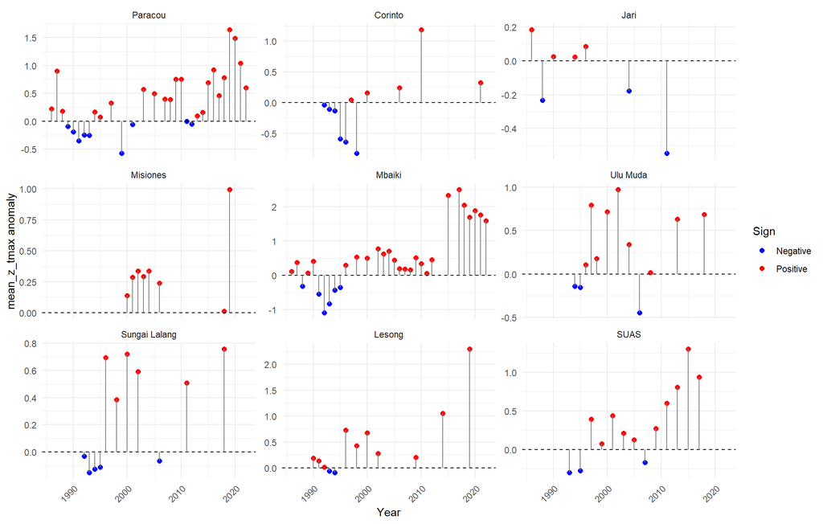

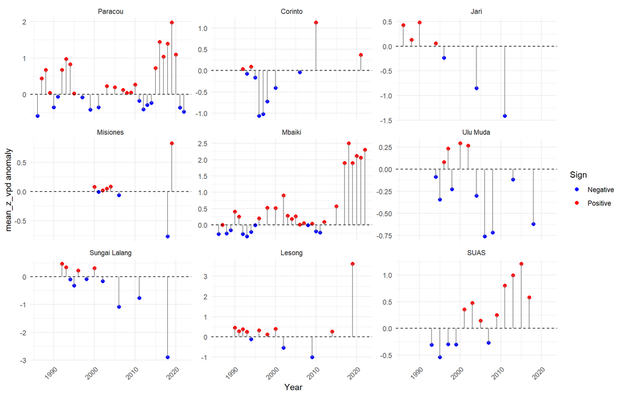

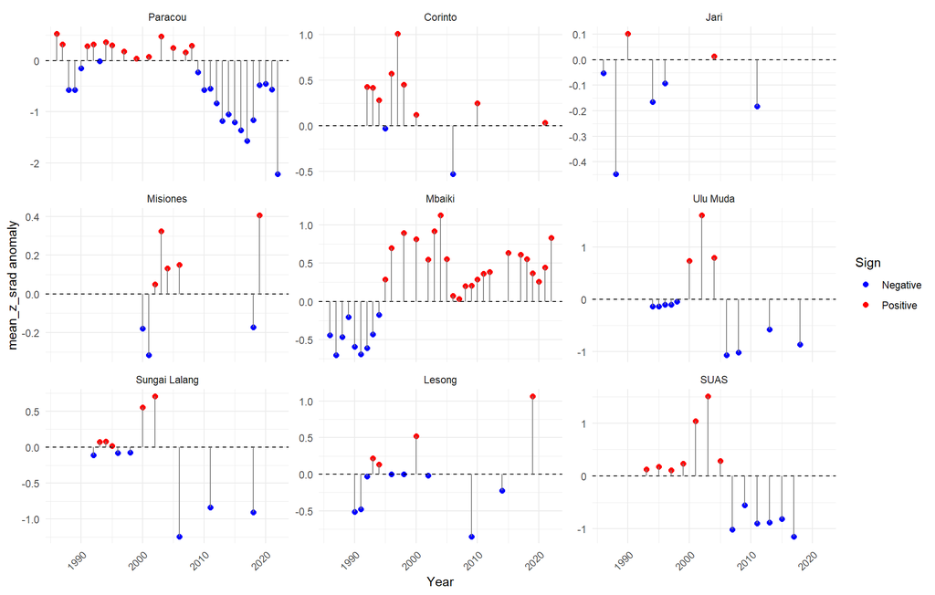

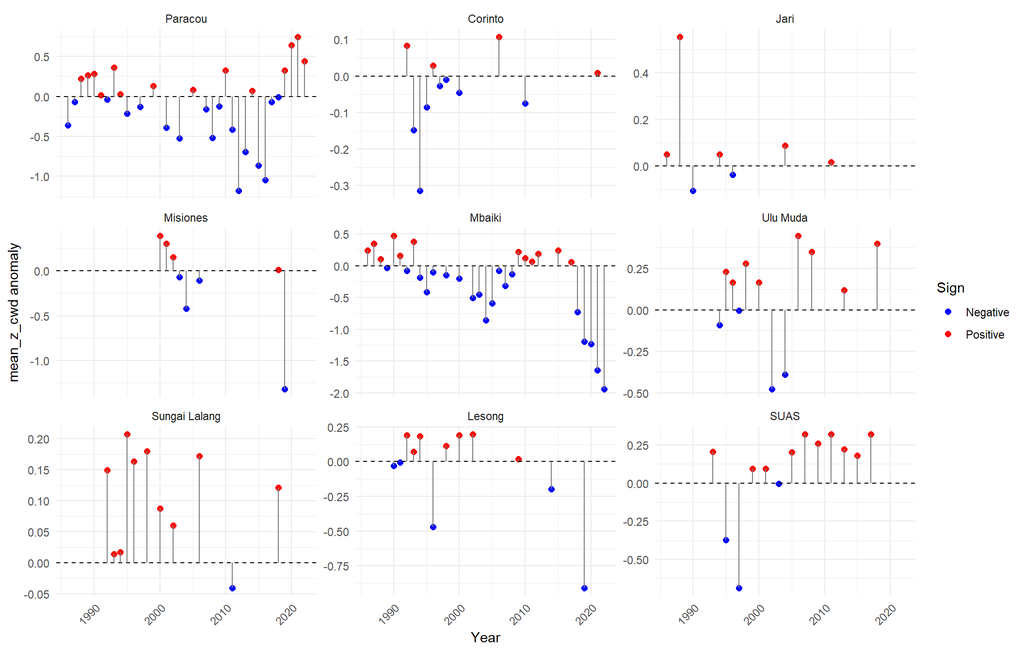

```r
site_order <- c(
  "Paracou", "Corinto", "Jari", "Misiones",
  "Mbaiki",
  "Ulu Muda", "Sungai Lalang", "Lesong", "SUAS"
)

vars <- c("mean_z_tmax", "mean_z_vpd",
          "mean_z_srad", "mean_z_cwd")




merged_census_anom[, site := factor(site, levels = site_order)]

merged_census_anom[, interval_num := as.numeric(sub("_.*", "", interval))]

for(v in vars){

plot_census_anom <- merged_census_anom[,
  .(value = mean(get(v), na.rm = TRUE)),  # collapse multiple values
  by = .(site, interval_num)
]


p <- ggplot(plot_census_anom, aes(x = interval_num, y = value)) +
  geom_point(aes(color = value >= 0), size = 2) +
  geom_hline(yintercept = 0, linetype = "dashed") +
  geom_segment(aes(x = interval_num, xend = interval_num, y = 0, yend = value),
               color = "grey50") +
  facet_wrap(~ site, scales = "free_y") +
  scale_color_manual(values = c("TRUE" = "red", "FALSE" = "blue"),
                     labels = c("Negative", "Positive")) +
  labs(x = "Year", y = paste(v, "anomaly"), color = "Sign") +
  theme_minimal() +
  theme(axis.text.x = element_text(angle = 45, hjust = 1))

print(p)

}
```

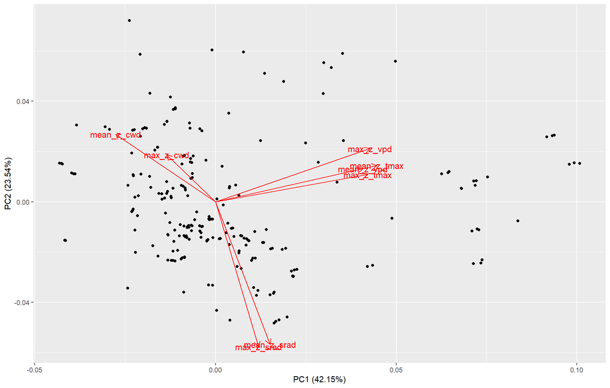

```r
  # for autoplot of PCA

data_num <- merged_census_anom %>%
  select(contains("z"))

pca_res <- prcomp(data_num, scale. = TRUE)

autoplot(pca_res,
         data = merged_census_anom,
         loadings = TRUE,       # show variable arrows
         loadings.label = TRUE,
         loadings.label.size = 4,
         frame = F)          # optional, draws group ellipses
```

```r
#cor.test(merged_census_anom$mean_z_srad, merged_census_anom$mean_z_cwd) #Negative SRAD–CWD correlation in anomalies reflects how deviations co-occur, not absolute drought mechanisms.


vars <- c("mean_z_tmax", "mean_z_vpd", "mean_z_srad", "mean_z_cwd")

clim <- merged_census_anom[, ..vars]


cor_matrix <- cor(clim, use = "pairwise.complete.obs")
print(cor_matrix)
```

```
            mean_z_tmax mean_z_vpd mean_z_srad mean_z_cwd
mean_z_tmax   1.0000000  0.6876570   0.1283816 -0.3317963
mean_z_vpd    0.6876570  1.0000000   0.1570388 -0.3445653
mean_z_srad   0.1283816  0.1570388   1.0000000 -0.3168307
mean_z_cwd   -0.3317963 -0.3445653  -0.3168307  1.0000000
```

#PC1- temperature related (temp and vpd - increased temperarture, increased evaporative demande - reduced stomatal conductance) #PC2 - soil water deficit (cwd) and cloud cover/seasonality (srad)

##Understanding MEAN climatic differences

```r
vars_keep <- c("srad", "tmax", "vpd", "ppt","cwd")


clim_long <- merged_clim_site %>%
  select(1:4, all_of(vars_keep)) %>%
  pivot_longer(
    cols = all_of(vars_keep),
    names_to = "variable",
    values_to = "value"
  )
```

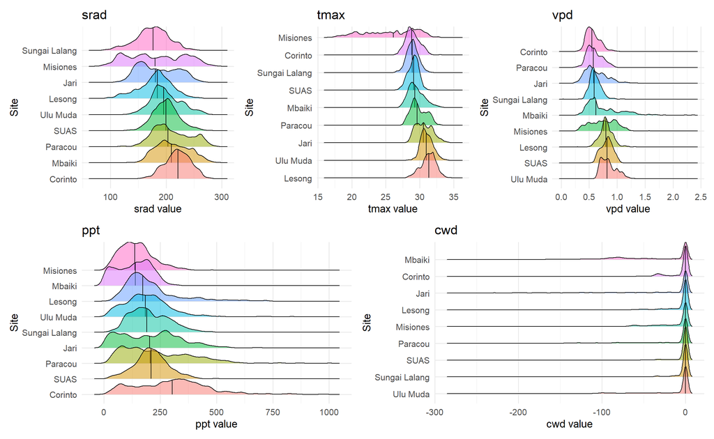

```r
# make a list to store individual plots
plot_list <- list()

# loop over each variable
for (v in unique(clim_long$variable)) {

  clim_var <- clim_long %>%
    filter(variable == v) %>%
    # reorder sites low -> high for this variable
    mutate(site_ordered = fct_rev(fct_reorder(site, value)))

  p <- ggplot(clim_var, aes(x = value, y = site_ordered, fill = site_ordered)) +
    ggridges::geom_density_ridges(alpha = 0.5, scale = 2, quantile_lines = TRUE, quantiles = 0.5) +
    labs(
      x = paste(v, "value"),
      y = "Site",
      title = v
    ) +
    theme_minimal(base_size = 14) +
    theme(legend.position = "none")

  plot_list[[v]] <- p  # store plot in list
}

# merge all plots in a grid (2x2 layout)
merged_plot <-
  (plot_list[[1]] | plot_list[[2]] | plot_list[[3]]) /
  (plot_list[[4]] | plot_list[[5]])

# display merged plot

merged_plot
```

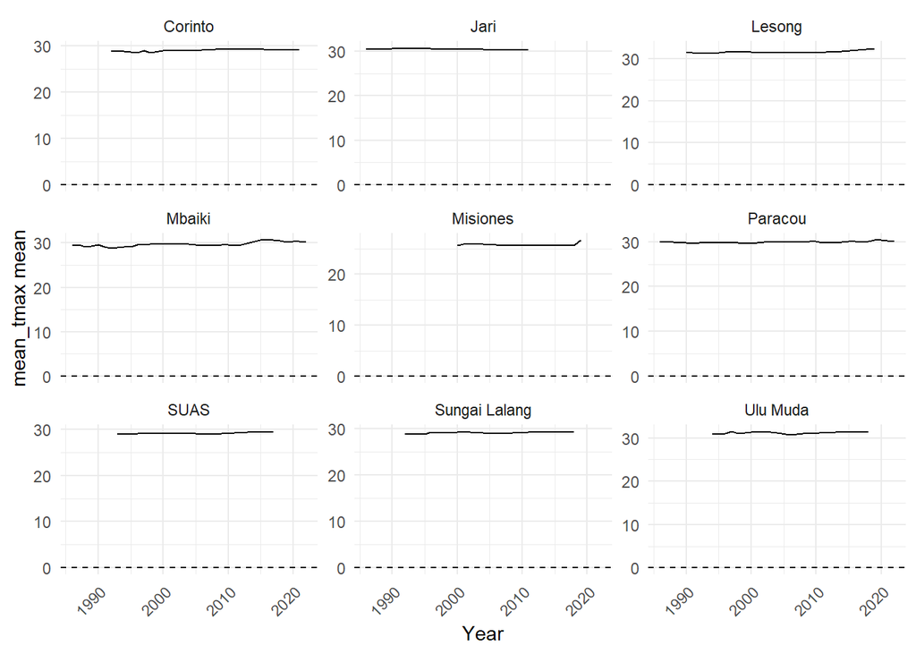

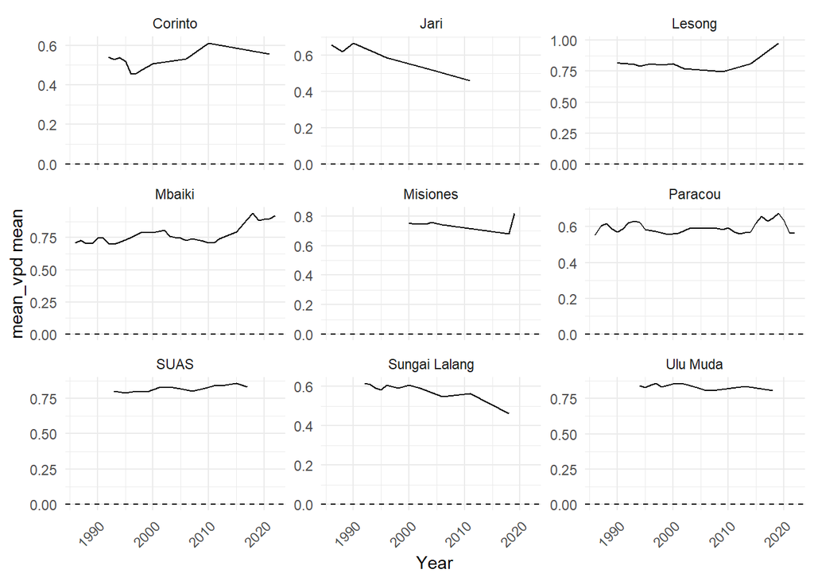

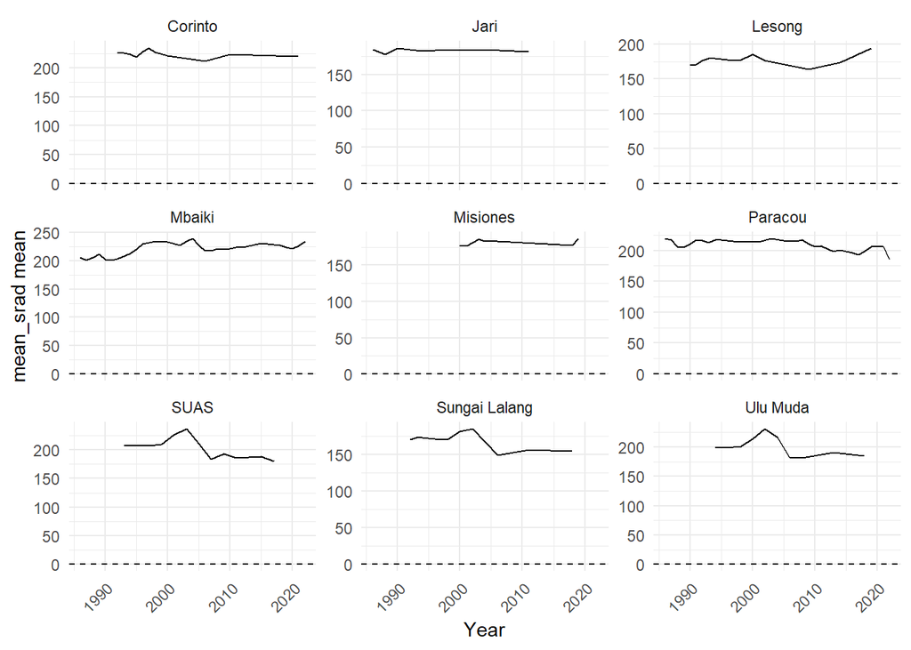

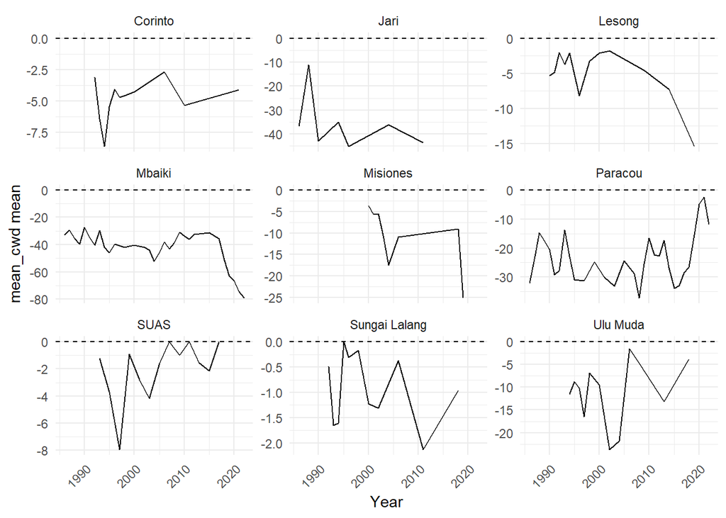

```r
vars <- c("mean_tmax", "mean_vpd",
          "mean_srad", "mean_cwd")

#merged[, site := factor(site, levels = site_order)]


for(v in vars){

plot_census_anom <- merged[,
  .(value = mean(get(v), na.rm = TRUE)),  # collapse multiple values
  by = .(site, year)
]


p <- ggplot(plot_census_anom, aes(x = year, y = value)) +
  geom_line() +
  geom_hline(yintercept = 0, linetype = "dashed") +
  facet_wrap(~ site, scales = "free_y") +
  labs(x = "Year", y = paste(v, "mean"), color = "Sign") +
  theme_minimal() +
  theme(axis.text.x = element_text(angle = 45, hjust = 1))

print(p)

}
```

## Generate model residuals with BAM

#agb gain (agb_growth + agb_recr)

```r
merged <- merged %>%
  mutate(
    plot = as.factor(plot),
    subplot = as.factor(subplot),
    treatment = as.factor(treatment),
    interval_num = as.numeric(sub("_.*", "", interval)),
    agb_gain = agb_growth + agb_recr,
    dagb = agb_growth + agb_recr - agb_mort
  )

setDT(merged)

site_models <- list()


for (s in sites) {
  merged_site <- merged[site == s]
  site_models[[s]] <- list()

  AR <- ave(merged_site$interval_num, merged_site$subplot, FUN = function(x) x == min(x)) |> as.logical()#TRUE for the first census year per subplot

    # choose k based on unique years

  ny <- uniqueN(merged_site$interval_num)

  k_use <- fifelse(ny <= 20, 3,
          fifelse(ny <= 25, 5, 7))

  cat("Site:", s, "- unique years:", uniqueN(merged_site$interval_num), "- k used:", k_use, "\n")

    # ---- 1) baseline model (NO AR) - used to estimate rho
  m0 <- bam(
    agb_gain ~
      s(interval_num, k = k_use) +
      s(treatment, bs = "re") +
      s(subplot, bs = "re") +
      s(interval_num, subplot, bs = "fs", k = k_use),#continuous and categorical variable
    data = merged_site,
    discrete = FALSE
  )


mf0 <- model.frame(m0)

res0 <- resid(m0, type = "response")

# Compute lag-1 autocorrelation for each subplot separately

acf_list <- lapply(split(res0, mf0$subplot), function(x) {
  if(length(x) < 3) return(NA_real_)
  acf(x, plot = FALSE)$acf[2]
})

# Pick the largest absolute lag-1 among all subplots for the site
# This ensures that rho0 captures the strongest temporal correlation present
rho0 <- max(abs(unlist(acf_list)), na.rm = TRUE)
rho0 <- max(min(rho0, 0.8), 0)

  cat("  estimated rho:", round(rho0, 3), "\n")


  # fit BAM
    mod <- bam(
      agb_gain ~ s(interval_num, k = k_use)+
        s(treatment, bs="re") +
                   s(subplot, bs="re") +
                   s(interval_num, subplot, bs="fs", k=k_use),
      data = merged_site,
      rho = rho0,
      AR.start = AR,
      discrete = F#T is for very large datasets, some accuracy is traded for speed
    )

  res <- residuals(mod, type="response")

mf <- model.frame(mod)

acf_res <- tapply(
  res,
  mf$subplot,
  function(x) {
    if (length(x) < 3) return(NULL)
    acf(x, plot = FALSE)
  }
)
      site_models[[s]]<- list(
      model = mod,
      rho = rho0,
      residuals = res,
      acf = acf_res
    )

#print(acf_res)[[s]]#Mbaiki: residuals 10 years apart are still correlated at ~0.59.lag-1 = consecutive censuses, lag-2 = two censuses apart

}



res_plot <- rbindlist(
  lapply(names(site_models), function(s) {
    df_site <- merged[site == s]

    # only rows used in BAM
    used <- !is.na(df_site$agb_gain)

    data.table(
      site = s,
      interval_num = df_site$interval_num[used],
      subplot = df_site$subplot[used],
      residual = site_models[[s]]$residuals
    )
  })
)



invisible(NULL)
```

## Plot BAM

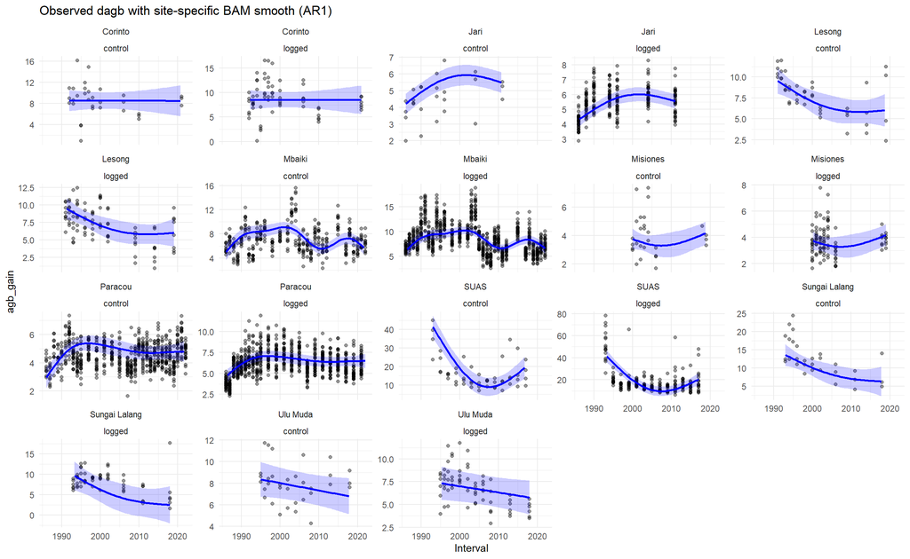

```r
# ==========================================================
# 1. EXTRACT PREDICTIONS PER SITE (ON RESPONSE SCALE)
# ==========================================================

smooth_list <- list()
raw_list <- list()

for (s in names(site_models)) {

  mod <- site_models[[s]]$model

  # Original model data
  dat <- model.frame(mod)

  dat$treatment <- as.factor(dat$treatment)
  dat$subplot   <- as.factor(dat$subplot)

  # Store raw data for plotting
  raw_df <- dat %>%
    mutate(site = s)

  raw_list[[s]] <- raw_df

  # Prediction grid across interval range
  newdata <- data.frame(
    interval_num = seq(
      min(dat$interval_num),
      max(dat$interval_num),
      length.out = 100
    ),
    treatment = levels(dat$treatment),
    subplot   = dat$subplot[1]     # arbitrary level
  )

  newdata$treatment <- factor(newdata$treatment,
                            levels = levels(dat$treatment))

newdata$subplot <- factor(newdata$subplot,
                          levels = levels(dat$subplot))

  # Predict full response (AGB gain) including intercept and smooths
  pred <- predict(
    mod,
    newdata = newdata,
    type = "response",
    se.fit = TRUE
  )

  # Build dataframe
  df_smooth <- data.frame(
    site = s,
    interval_num = newdata$interval_num,
    fit = pred$fit,
    se  = pred$se.fit,
    treatment=newdata$treatment
  )

  smooth_list[[s]] <- df_smooth
}

# Combine all sites
smooth_df <- bind_rows(smooth_list)
raw_df_all <- bind_rows(raw_list)

# ==========================================================
# 2. PLOT RAW DATA + SMOOTH
# ==========================================================

p <- ggplot() +

  # Raw points
  geom_point(
    data = raw_df_all,
    aes(x = interval_num, y = agb_gain),
    alpha = 0.4,
    size = 1.5
  ) +

  # Smooth line (predicted AGB gain)
  geom_line(
    data = smooth_df,
    aes(x = interval_num, y = fit),
    linewidth = 1,
    color = "blue"
  ) +

  # 95% confidence ribbon
  geom_ribbon(
    data = smooth_df,
    aes(
      x = interval_num,
      ymin = fit - 2 * se,
      ymax = fit + 2 * se
    ),
    alpha = 0.2,
    fill = "blue"
  ) +

  facet_wrap(~ site+treatment, scales = "free_y") +

  labs(
    x = "Interval",
    y = "agb_gain",
    title = "Observed dagb with site-specific BAM smooth (AR1)"
  ) +

  theme_minimal()

print(p)
```

## causal inference framework:

#We can test for total causal effects (TCE) and/or direct causal effects (DCE). #TCEs include all downstream variables (e.g., the effect of Tmax on agb gain, including it’s effect via VPD, etc). #DCEs include direct causal pathways only (e.g., the effect of Tmax on agb gain, excluding it’s effect via VPD).

#Tmax anomaly - TCE

```r
#cor.test(merged$mean_z_tmax, merged$mean_z_srad)#confirm srad is a confounder

site_models2<- list()

table_results_combined <- list()

for (s in sites) {
  merged_site <- merged[site == s]

  # choose k based on unique years
    ny <- uniqueN(merged_site$interval_num)

  k_use <- fifelse(ny <= 20, 3,
          fifelse(ny <= 25, 5, 7))

  #cat("Site:", s, "- unique years:", uniqueN(merged_site$interval_num), "- k used:", k_use, "\n")


  AR <- ave(merged_site$interval_num, merged_site$subplot, FUN = function(x) x == min(x)) |> as.logical()

    # ---- 1) baseline model (NO AR) - used to estimate rho
  m0 <- bam(
    agb_gain ~
      s(interval_num, k = k_use) +
      s(treatment, bs = "re") +
      s(subplot, bs = "re") +
      s(interval_num, subplot, bs = "fs", k = k_use)+
          mean_z_tmax:treatment+mean_z_srad,
    data = merged_site,
    discrete = FALSE
  )

mf0 <- model.frame(m0)

res0 <- resid(m0, type = "response")

# Compute lag-1 autocorrelation for each subplot separately

acf_list <- lapply(split(res0, mf0$subplot), function(x) {
  if(length(x) < 3) return(NA_real_)
  acf(x, plot = FALSE)$acf[2]
})

# Pick the largest absolute lag-1 among all subplots for the site
# This ensures that rho0 captures the strongest temporal correlation present
rho0 <- max(abs(unlist(acf_list)), na.rm = TRUE)
rho0 <- max(min(rho0, 0.8), 0)

  #cat("  estimated rho:", round(rho0, 3), "\n")

    # fit BAM
  mod3 <- bam(
    agb_gain ~
      s(interval_num, k = k_use) +
      s(treatment, bs="re") +
      s(subplot, bs="re")+
      s(interval_num, subplot, bs="fs", k=k_use)+
          mean_z_tmax:treatment+mean_z_srad,
    data = merged_site,
    rho = rho0,
    AR.start = AR,
    discrete = FALSE
  )

  #

  #plot(mod3, select=1)

  res <- residuals(mod3, type="response")

mf <- model.frame(mod3)

acf_res <- tapply(
  res,
  mf$subplot,
  function(x) {
    if (length(x) < 3) return(NULL)
    acf(x, plot = FALSE)
  }
)
      site_models2[[s]]<- list(
      model = mod3,
      rho = rho0,
      residuals = res,
      acf = acf_res
    )

  param_tab3  <- broom::tidy(mod3, parametric = TRUE) %>% mutate(Term_type = "parametric")
  smooth_tab3 <- broom::tidy(mod3, parametric = FALSE) %>% mutate(Term_type = "smooth")
  tab_mod3    <- bind_rows(param_tab3, smooth_tab3) %>%
                    mutate(Model_type = "BAM_re",
                           Model = s)


  # ---- combine both models for this site ----
  table_results_combined[[s]] <- bind_rows(tab_mod3)
}

# combine all sites into one table
final_table_combined <- bind_rows(table_results_combined)

final_table_combined <- final_table_combined %>%
  filter(grepl("treatment", term))

res_plot2 <- rbindlist(
  lapply(names(site_models2), function(s) {
    df_site <- merged[site == s]

    # only rows used in BAM
    used <- !is.na(df_site$agb_gain)

    data.table(
      site = s,
      interval_num = df_site$interval_num[used],
      subplot = df_site$subplot[used],
      residual = site_models[[s]]$residuals
    )
  })
)
```

## model fit diagnostics

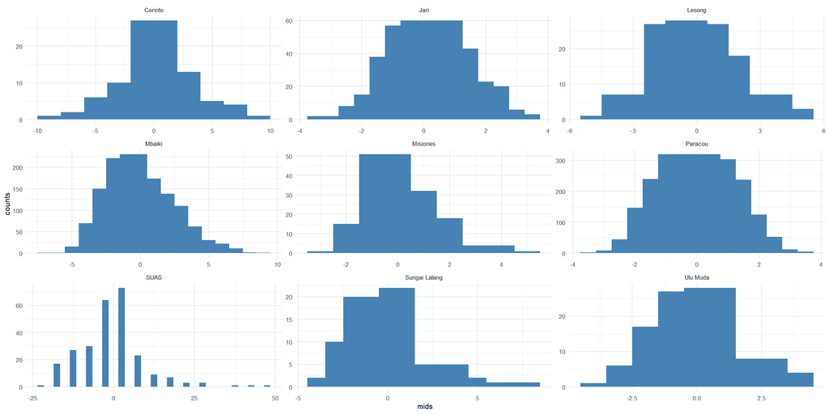

```r
res_plot2$site <- factor(res_plot2$site, levels = unique(res_plot2$site))

hist_df <- res_plot2 %>%
  group_by(site) %>%
  do({
    h <- hist(.$residual, plot = FALSE)
    data.frame(
      site = unique(.$site),
      mids = h$mids,
      counts = h$counts,
      width = diff(h$breaks)[1]
    )
  })

ggplot(hist_df, aes(x = mids, y = counts)) +
  geom_col(width = hist_df$width[1], fill = "steelblue") +
  facet_wrap(~ site, scales = "free") +
  theme_minimal(base_size = 8)
```

###plot per treatment

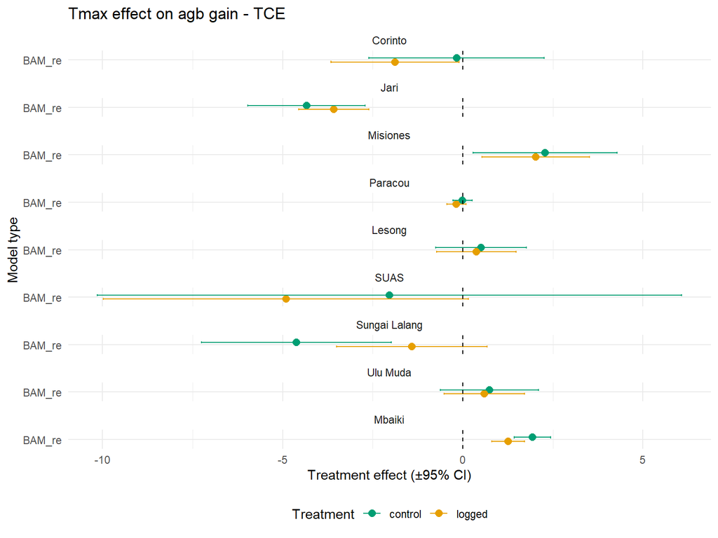

```r
final_plot_tmax <- final_table_combined %>%
  filter(
    Term_type == "parametric",
    grepl("treatment", term)
  ) %>%
  mutate(
    Treatment = gsub("mean_z_tmax:treatment", "", term)
  )

setDT(final_plot_tmax)


final_plot_tmax$Treatment <- factor(
  final_plot_tmax$Treatment,
  levels = rev(c("control","logged")),
  ordered = TRUE
)

final_plot_tmax$Model <- factor(
  final_plot_tmax$Model,
  levels = c("Corinto", "Jari", "Misiones", "Paracou",
             "Lesong", "SUAS", "Sungai Lalang",
             "Ulu Muda", "Mbaiki")
)

pd <- position_dodge(width = 0.5)

    p <- ggplot(
      final_plot_tmax,
      aes(
        x = estimate,
        y = Model_type,
        color = Treatment, group = Treatment
      )
    ) +
  geom_point(aes(color = Treatment, group = Treatment), position = position_dodge(0.5),size = 2.5) +
      geom_errorbarh(
        aes(
          xmin = estimate - 1.96 * std.error,
          xmax = estimate + 1.96 * std.error
        ),
        height = 0.25,
          position = pd
      ) +
      geom_vline(xintercept = 0, linetype = "dashed") +
        scale_color_manual(values = c("control" = "#009E73", "logged" = "#E69F00"),
  breaks = c("control", "logged")) +
      facet_wrap(~ Model, ncol = 1) +
      labs(
        x = "Treatment effect (±95% CI)",
        y = "Model type",
        title = paste(
          "Tmax effect on agb gain - TCE"
        )
      ) +
      theme_minimal()

p <- p +
  theme(
    legend.position = "bottom"
  )
    print(p)
```

#Tmax - DCE

```r
#cor.test(merged$mean_z_tmax, merged$mean_z_srad)#confirm srad is a confounder

site_models2<- list()

table_results_combined <- list()

for (s in sites) {
  merged_site <- merged[site == s]

  # choose k based on unique years
    ny <- uniqueN(merged_site$interval_num)

  k_use <- fifelse(ny <= 20, 3,
          fifelse(ny <= 25, 5, 7))

  #cat("Site:", s, "- unique years:", uniqueN(merged_site$interval_num), "- k used:", k_use, "\n")


  AR <- ave(merged_site$interval_num, merged_site$subplot, FUN = function(x) x == min(x)) |> as.logical()

    # ---- 1) baseline model (NO AR) - used to estimate rho
  m0 <- bam(
    agb_gain ~
      s(interval_num, k = k_use) +
      s(treatment, bs = "re") +
      s(subplot, bs = "re") +
      s(interval_num, subplot, bs = "fs", k = k_use)+
          mean_z_tmax:treatment+mean_z_srad+mean_z_vpd+mean_z_cwd,#here we block the effect of vpd and cwd
    data = merged_site,
    discrete = FALSE
  )

mf0 <- model.frame(m0)

res0 <- resid(m0, type = "response")

# Compute lag-1 autocorrelation for each subplot separately

acf_list <- lapply(split(res0, mf0$subplot), function(x) {
  if(length(x) < 3) return(NA_real_)
  acf(x, plot = FALSE)$acf[2]
})

# Pick the largest absolute lag-1 among all subplots for the site
# This ensures that rho0 captures the strongest temporal correlation present
rho0 <- max(abs(unlist(acf_list)), na.rm = TRUE)
rho0 <- max(min(rho0, 0.8), 0)

  #cat("  estimated rho:", round(rho0, 3), "\n")

    # fit BAM
  mod3 <- bam(
    agb_gain ~
      s(interval_num, k = k_use) +
      s(treatment, bs="re") +
      s(subplot, bs="re")+
      s(interval_num, subplot, bs="fs", k=k_use)+
          mean_z_tmax:treatment+mean_z_srad+mean_z_vpd+mean_z_cwd,
    data = merged_site,
    rho = rho0,
    AR.start = AR,
    discrete = FALSE
  )

  #

  #plot(mod3, select=1)

  res <- residuals(mod3, type="response")

mf <- model.frame(mod3)

acf_res <- tapply(
  res,
  mf$subplot,
  function(x) {
    if (length(x) < 3) return(NULL)
    acf(x, plot = FALSE)
  }
)
      site_models2[[s]]<- list(
      model = mod3,
      rho = rho0,
      residuals = res,
      acf = acf_res
    )

  param_tab3  <- broom::tidy(mod3, parametric = TRUE) %>% mutate(Term_type = "parametric")
  smooth_tab3 <- broom::tidy(mod3, parametric = FALSE) %>% mutate(Term_type = "smooth")
  tab_mod3    <- bind_rows(param_tab3, smooth_tab3) %>%
                    mutate(Model_type = "BAM_re",
                           Model = s)


  # ---- combine both models for this site ----
  table_results_combined[[s]] <- bind_rows(tab_mod3)
}

# combine all sites into one table
final_table_combined <- bind_rows(table_results_combined)

final_table_combined <- final_table_combined %>%
  filter(grepl("treatment", term))

res_plot2 <- rbindlist(
  lapply(names(site_models2), function(s) {
    df_site <- merged[site == s]

    # only rows used in BAM
    used <- !is.na(df_site$agb_gain)

    data.table(
      site = s,
      interval_num = df_site$interval_num[used],
      subplot = df_site$subplot[used],
      residual = site_models[[s]]$residuals
    )
  })
)



m=lm(agb_gain ~ mean_z_tmax + mean_z_vpd + mean_z_srad + mean_z_cwd,
       data = merged)


check_collinearity(m)#how much the variance of a coefficient increases because predictors are correlated
```

```
# Check for Multicollinearity

Low Correlation

        Term  VIF   VIF 95% CI adj. VIF Tolerance Tolerance 95% CI
 mean_z_tmax 2.05 [1.96, 2.15]     1.43      0.49     [0.46, 0.51]
  mean_z_vpd 2.16 [2.06, 2.27]     1.47      0.46     [0.44, 0.49]
 mean_z_srad 1.09 [1.06, 1.13]     1.04      0.92     [0.88, 0.95]
  mean_z_cwd 1.25 [1.21, 1.30]     1.12      0.80     [0.77, 0.83]
```

###plot per treatment

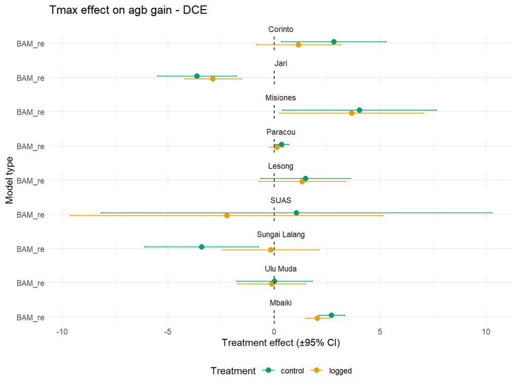

```r
final_plot_tmax2 <- final_table_combined %>%
  filter(
    Term_type == "parametric",
    grepl("treatment", term)
  ) %>%
  mutate(
    Treatment = gsub("mean_z_tmax:treatment", "", term)
  )

setDT(final_plot_tmax2)


final_plot_tmax2$Treatment <- factor(
  final_plot_tmax2$Treatment,
  levels = rev(c("control","logged")),
  ordered = TRUE
)


final_plot_tmax2$Model <- factor(
  final_plot_tmax2$Model,
  levels = c("Corinto", "Jari", "Misiones", "Paracou",
             "Lesong", "SUAS", "Sungai Lalang",
             "Ulu Muda", "Mbaiki")
)


pd <- position_dodge(width = 0.5)

    p <- ggplot(
      final_plot_tmax2,
      aes(
        x = estimate,
        y = Model_type,
        color = Treatment, group = Treatment
      )
    ) +
  geom_point(aes(color = Treatment, group = Treatment), position = position_dodge(0.5),size = 2.5) +
      geom_errorbarh(
        aes(
          xmin = estimate - 1.96 * std.error,
          xmax = estimate + 1.96 * std.error
        ),
        height = 0.25,
          position = pd
      ) +
      geom_vline(xintercept = 0, linetype = "dashed") +
        scale_color_manual(values = c("control" = "#009E73", "logged" = "#E69F00"),
  breaks = c("control", "logged")) +
      facet_wrap(~ Model, ncol = 1) +
      labs(
        x = "Treatment effect (±95% CI)",
        y = "Model type",
        title = paste(
          "Tmax effect on agb gain - DCE"
        )
      ) +
      theme_minimal()
   p <- p +
  theme(
    legend.position = "bottom"
  )

    print(p)
```

#VPD - TCE

```r
#cor.test(merged$mean_z_vpd, merged$mean_z_srad)#confirm srad is a confounder (tmax and srad were already tested)



site_models2<- list()

table_results_combined <- list()

for (s in sites) {
  merged_site <- merged[site == s]

  # choose k based on unique years
    ny <- uniqueN(merged_site$interval_num)

  k_use <- fifelse(ny <= 20, 3,
          fifelse(ny <= 25, 5, 7))

  #cat("Site:", s, "- unique years:", uniqueN(merged_site$interval_num), "- k used:", k_use, "\n")


  AR <- ave(merged_site$interval_num, merged_site$subplot, FUN = function(x) x == min(x)) |> as.logical()

    # ---- 1) baseline model (NO AR) - used to estimate rho
  m0 <- bam(
    agb_gain ~
      s(interval_num, k = k_use) +
      s(treatment, bs = "re") +
      s(subplot, bs = "re") +
      s(interval_num, subplot, bs = "fs", k = k_use)+
          mean_z_vpd:treatment+mean_z_srad+mean_z_tmax,
    data = merged_site,
    discrete = FALSE
  )

mf0 <- model.frame(m0)

res0 <- resid(m0, type = "response")

# Compute lag-1 autocorrelation for each subplot separately

acf_list <- lapply(split(res0, mf0$subplot), function(x) {
  if(length(x) < 3) return(NA_real_)
  acf(x, plot = FALSE)$acf[2]
})

# Pick the largest absolute lag-1 among all subplots for the site
# This ensures that rho0 captures the strongest temporal correlation present
rho0 <- max(abs(unlist(acf_list)), na.rm = TRUE)
rho0 <- max(min(rho0, 0.8), 0)

  #cat("  estimated rho:", round(rho0, 3), "\n")

    # fit BAM
  mod3 <- bam(
    agb_gain ~
      s(interval_num, k = k_use) +
      s(treatment, bs="re") +
      s(subplot, bs="re")+
      s(interval_num, subplot, bs="fs", k=k_use)+
          mean_z_vpd:treatment+mean_z_srad+mean_z_tmax,
    data = merged_site,
    rho = rho0,
    AR.start = AR,
    discrete = FALSE
  )

  #

  #plot(mod3, select=1)

  res <- residuals(mod3, type="response")

mf <- model.frame(mod3)

acf_res <- tapply(
  res,
  mf$subplot,
  function(x) {
    if (length(x) < 3) return(NULL)
    acf(x, plot = FALSE)
  }
)
      site_models2[[s]]<- list(
      model = mod3,
      rho = rho0,
      residuals = res,
      acf = acf_res
    )

  param_tab3  <- broom::tidy(mod3, parametric = TRUE) %>% mutate(Term_type = "parametric")
  smooth_tab3 <- broom::tidy(mod3, parametric = FALSE) %>% mutate(Term_type = "smooth")
  tab_mod3    <- bind_rows(param_tab3, smooth_tab3) %>%
                    mutate(Model_type = "BAM_re",
                           Model = s)


  # ---- combine both models for this site ----
  table_results_combined[[s]] <- bind_rows(tab_mod3)
}

# combine all sites into one table
final_table_combined <- bind_rows(table_results_combined)

final_table_combined <- final_table_combined %>%
  filter(grepl("treatment", term))

res_plot2 <- rbindlist(
  lapply(names(site_models2), function(s) {
    df_site <- merged[site == s]

    # only rows used in BAM
    used <- !is.na(df_site$agb_gain)

    data.table(
      site = s,
      interval_num = df_site$interval_num[used],
      subplot = df_site$subplot[used],
      residual = site_models[[s]]$residuals
    )
  })
)
```

###plot per treatment

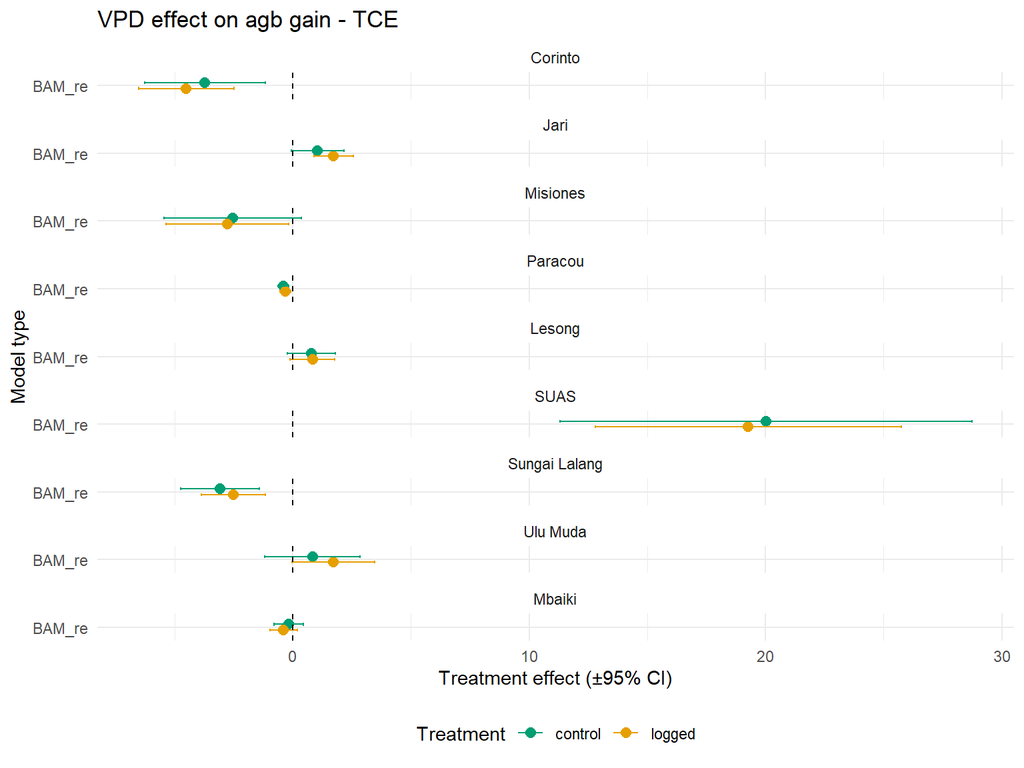

```r
final_plot_vpd <- final_table_combined %>%
  filter(
    Term_type == "parametric",
    grepl("treatment", term)
  ) %>%
  mutate(
    Treatment = gsub("mean_z_vpd:treatment", "", term)
  )

setDT(final_plot_vpd)


final_plot_vpd$Treatment <- factor(
  final_plot_vpd$Treatment,
  levels = rev(c("control","logged")),
  ordered = TRUE
)

final_plot_vpd$Model <- factor(
  final_plot_vpd$Model,
  levels = c("Corinto", "Jari", "Misiones", "Paracou",
             "Lesong", "SUAS", "Sungai Lalang",
             "Ulu Muda", "Mbaiki")
)


pd <- position_dodge(width = 0.5)

    p <- ggplot(
      final_plot_vpd,
      aes(
        x = estimate,
        y = Model_type,
        color = Treatment, group = Treatment
      )
    ) +
  geom_point(aes(color = Treatment, group = Treatment), position = position_dodge(0.5),size = 2.5) +
      geom_errorbarh(
        aes(
          xmin = estimate - 1.96 * std.error,
          xmax = estimate + 1.96 * std.error
        ),
        height = 0.25,
          position = pd
      ) +
      geom_vline(xintercept = 0, linetype = "dashed") +
        scale_color_manual(values = c("control" = "#009E73", "logged" = "#E69F00"),
  breaks = c("control", "logged")) +
      facet_wrap(~ Model, ncol = 1) +
      labs(
        x = "Treatment effect (±95% CI)",
        y = "Model type",
        title = paste(
          "VPD effect on agb gain - TCE"
        )
      ) +
      theme_minimal()

p <- p +
  theme(
    legend.position = "bottom"
  )
    print(p)
```

#VPD - DCE

```r
site_models2<- list()

table_results_combined <- list()

for (s in sites) {
  merged_site <- merged[site == s]

  # choose k based on unique years
    ny <- uniqueN(merged_site$interval_num)

  k_use <- fifelse(ny <= 20, 3,
          fifelse(ny <= 25, 5, 7))

  #cat("Site:", s, "- unique years:", uniqueN(merged_site$interval_num), "- k used:", k_use, "\n")


  AR <- ave(merged_site$interval_num, merged_site$subplot, FUN = function(x) x == min(x)) |> as.logical()

    # ---- 1) baseline model (NO AR) - used to estimate rho
  m0 <- bam(
    agb_gain ~
      s(interval_num, k = k_use) +
      s(treatment, bs = "re") +
      s(subplot, bs = "re") +
      s(interval_num, subplot, bs = "fs", k = k_use)+
          mean_z_vpd:treatment+mean_z_srad+mean_z_tmax+mean_z_cwd,
    data = merged_site,
    discrete = FALSE
  )

mf0 <- model.frame(m0)

res0 <- resid(m0, type = "response")

# Compute lag-1 autocorrelation for each subplot separately

acf_list <- lapply(split(res0, mf0$subplot), function(x) {
  if(length(x) < 3) return(NA_real_)
  acf(x, plot = FALSE)$acf[2]
})

# Pick the largest absolute lag-1 among all subplots for the site
# This ensures that rho0 captures the strongest temporal correlation present
rho0 <- max(abs(unlist(acf_list)), na.rm = TRUE)
rho0 <- max(min(rho0, 0.8), 0)

  #cat("  estimated rho:", round(rho0, 3), "\n")

    # fit BAM
  mod3 <- bam(
    agb_gain ~
      s(interval_num, k = k_use) +
      s(treatment, bs="re") +
      s(subplot, bs="re")+
      s(interval_num, subplot, bs="fs", k=k_use)+
          mean_z_vpd:treatment+mean_z_srad+mean_z_tmax+mean_z_cwd,
    data = merged_site,
    rho = rho0,
    AR.start = AR,
    discrete = FALSE
  )

  #

  #plot(mod3, select=1)

  res <- residuals(mod3, type="response")

mf <- model.frame(mod3)

acf_res <- tapply(
  res,
  mf$subplot,
  function(x) {
    if (length(x) < 3) return(NULL)
    acf(x, plot = FALSE)
  }
)
      site_models2[[s]]<- list(
      model = mod3,
      rho = rho0,
      residuals = res,
      acf = acf_res
    )

  param_tab3  <- broom::tidy(mod3, parametric = TRUE) %>% mutate(Term_type = "parametric")
  smooth_tab3 <- broom::tidy(mod3, parametric = FALSE) %>% mutate(Term_type = "smooth")
  tab_mod3    <- bind_rows(param_tab3, smooth_tab3) %>%
                    mutate(Model_type = "BAM_re",
                           Model = s)


  # ---- combine both models for this site ----
  table_results_combined[[s]] <- bind_rows(tab_mod3)
}

# combine all sites into one table
final_table_combined <- bind_rows(table_results_combined)

final_table_combined <- final_table_combined %>%
  filter(grepl("treatment", term))

res_plot2 <- rbindlist(
  lapply(names(site_models2), function(s) {
    df_site <- merged[site == s]

    # only rows used in BAM
    used <- !is.na(df_site$agb_gain)

    data.table(
      site = s,
      interval_num = df_site$interval_num[used],
      subplot = df_site$subplot[used],
      residual = site_models[[s]]$residuals
    )
  })
)
```

###plot per treatment

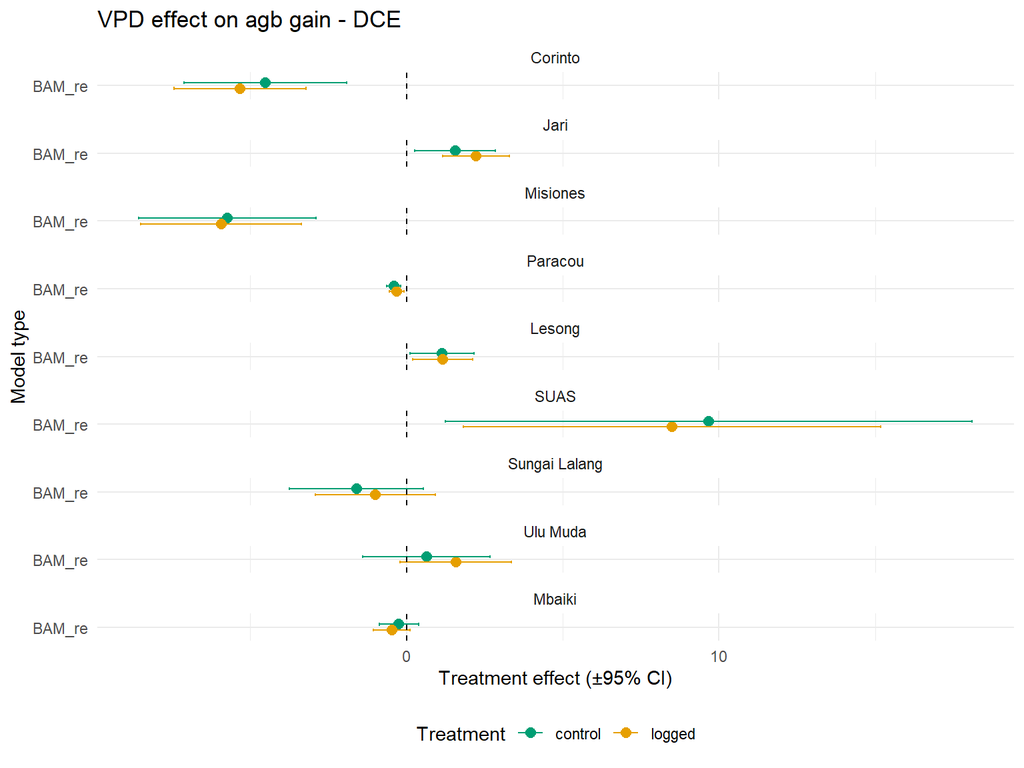

```r
final_plot_vpd2 <- final_table_combined %>%
  filter(
    Term_type == "parametric",
    grepl("treatment", term)
  ) %>%
  mutate(
    Treatment = gsub("mean_z_vpd:treatment", "", term)
  )

setDT(final_plot_vpd2)


final_plot_vpd2$Treatment <- factor(
  final_plot_vpd2$Treatment,
  levels = rev(c("control","logged")),
  ordered = TRUE
)

final_plot_vpd2$Model <- factor(
  final_plot_vpd2$Model,
  levels = c("Corinto", "Jari", "Misiones", "Paracou",
             "Lesong", "SUAS", "Sungai Lalang",
             "Ulu Muda", "Mbaiki")
)
pd <- position_dodge(width = 0.5)

    p <- ggplot(
      final_plot_vpd2,
      aes(
        x = estimate,
        y = Model_type,
        color = Treatment, group = Treatment
      )
    ) +
  geom_point(aes(color = Treatment, group = Treatment), position = position_dodge(0.5),size = 2.5) +
      geom_errorbarh(
        aes(
          xmin = estimate - 1.96 * std.error,
          xmax = estimate + 1.96 * std.error
        ),
        height = 0.25,
          position = pd
      ) +
      geom_vline(xintercept = 0, linetype = "dashed") +
        scale_color_manual(values = c("control" = "#009E73", "logged" = "#E69F00"),
  breaks = c("control", "logged")) +
      facet_wrap(~ Model, ncol = 1) +
      labs(
        x = "Treatment effect (±95% CI)",
        y = "Model type",
        title = paste(
          "VPD effect on agb gain - DCE"
        )
      ) +
      theme_minimal()

p <- p +
  theme(
    legend.position = "bottom"
  )
    print(p)
```

#SRAD - TCE

```r
site_models2<- list()

table_results_combined <- list()

for (s in sites) {
  merged_site <- merged[site == s]

  # choose k based on unique years
    ny <- uniqueN(merged_site$interval_num)

  k_use <- fifelse(ny <= 20, 3,
          fifelse(ny <= 25, 5, 7))

  #cat("Site:", s, "- unique years:", uniqueN(merged_site$interval_num), "- k used:", k_use, "\n")


  AR <- ave(merged_site$interval_num, merged_site$subplot, FUN = function(x) x == min(x)) |> as.logical()

    # ---- 1) baseline model (NO AR) - used to estimate rho
  m0 <- bam(
    agb_gain ~
      s(interval_num, k = k_use) +
      s(treatment, bs = "re") +
      s(subplot, bs = "re") +
      s(interval_num, subplot, bs = "fs", k = k_use)+
          mean_z_srad:treatment,
    data = merged_site,
    discrete = FALSE
  )

mf0 <- model.frame(m0)

res0 <- resid(m0, type = "response")

# Compute lag-1 autocorrelation for each subplot separately

acf_list <- lapply(split(res0, mf0$subplot), function(x) {
  if(length(x) < 3) return(NA_real_)
  acf(x, plot = FALSE)$acf[2]
})

# Pick the largest absolute lag-1 among all subplots for the site
# This ensures that rho0 captures the strongest temporal correlation present
rho0 <- max(abs(unlist(acf_list)), na.rm = TRUE)
rho0 <- max(min(rho0, 0.8), 0)

  #cat("  estimated rho:", round(rho0, 3), "\n")

    # fit BAM
  mod3 <- bam(
    agb_gain ~
      s(interval_num, k = k_use) +
      s(treatment, bs="re") +
      s(subplot, bs="re")+
      s(interval_num, subplot, bs="fs", k=k_use)+
          mean_z_srad:treatment,
    data = merged_site,
    rho = rho0,
    AR.start = AR,
    discrete = FALSE
  )

  #

  #plot(mod3, select=1)

  res <- residuals(mod3, type="response")

mf <- model.frame(mod3)

acf_res <- tapply(
  res,
  mf$subplot,
  function(x) {
    if (length(x) < 3) return(NULL)
    acf(x, plot = FALSE)
  }
)
      site_models2[[s]]<- list(
      model = mod3,
      rho = rho0,
      residuals = res,
      acf = acf_res
    )

  param_tab3  <- broom::tidy(mod3, parametric = TRUE) %>% mutate(Term_type = "parametric")
  smooth_tab3 <- broom::tidy(mod3, parametric = FALSE) %>% mutate(Term_type = "smooth")
  tab_mod3    <- bind_rows(param_tab3, smooth_tab3) %>%
                    mutate(Model_type = "BAM_re",
                           Model = s)


  # ---- combine both models for this site ----
  table_results_combined[[s]] <- bind_rows(tab_mod3)
}

# combine all sites into one table
final_table_combined <- bind_rows(table_results_combined)

final_table_combined <- final_table_combined %>%
  filter(grepl("treatment", term))

res_plot2 <- rbindlist(
  lapply(names(site_models2), function(s) {
    df_site <- merged[site == s]

    # only rows used in BAM
    used <- !is.na(df_site$agb_gain)

    data.table(
      site = s,
      interval_num = df_site$interval_num[used],
      subplot = df_site$subplot[used],
      residual = site_models[[s]]$residuals
    )
  })
)
```

###plot per treatment

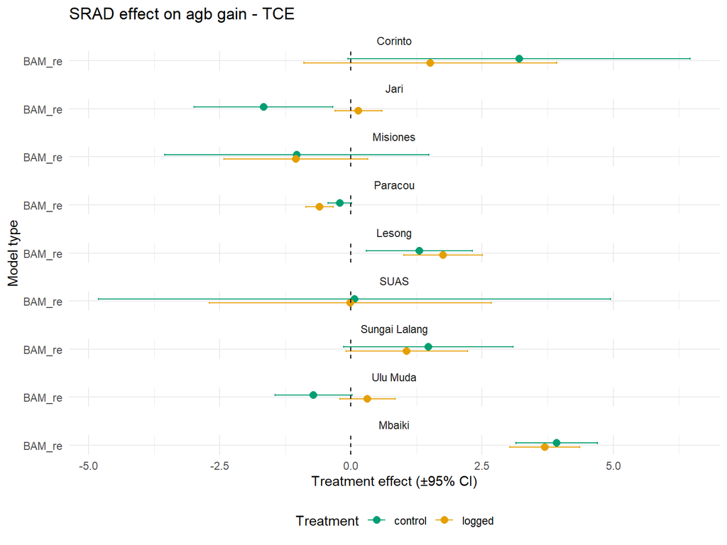

```r
final_plot_srad <- final_table_combined %>%
  filter(
    Term_type == "parametric",
    grepl("treatment", term)
  ) %>%
  mutate(
    Treatment = gsub("mean_z_srad:treatment", "", term)
  )

setDT(final_plot_srad)


final_plot_srad$Treatment <- factor(
  final_plot_srad$Treatment,
  levels = rev(c("control","logged")),
  ordered = TRUE
)

final_plot_srad$Model <- factor(
  final_plot_srad$Model,
  levels = c("Corinto", "Jari", "Misiones", "Paracou",
             "Lesong", "SUAS", "Sungai Lalang",
             "Ulu Muda", "Mbaiki")
)

pd <- position_dodge(width = 0.5)

    p <- ggplot(
      final_plot_srad,
      aes(
        x = estimate,
        y = Model_type,
        color = Treatment, group = Treatment
      )
    ) +
  geom_point(aes(color = Treatment, group = Treatment), position = position_dodge(0.5),size = 2.5) +
      geom_errorbarh(
        aes(
          xmin = estimate - 1.96 * std.error,
          xmax = estimate + 1.96 * std.error
        ),
        height = 0.25,
          position = pd
      ) +
      geom_vline(xintercept = 0, linetype = "dashed") +
        scale_color_manual(values = c("control" = "#009E73", "logged" = "#E69F00"),
  breaks = c("control", "logged")) +
      facet_wrap(~ Model, ncol = 1) +
      labs(
        x = "Treatment effect (±95% CI)",
        y = "Model type",
        title = paste(
          "SRAD effect on agb gain - TCE"
        )
      ) +
      theme_minimal()

p <- p +
  theme(
    legend.position = "bottom"
  )
    print(p)
```

#SRAD - DCE

```r
site_models2<- list()

table_results_combined <- list()

for (s in sites) {
  merged_site <- merged[site == s]

  # choose k based on unique years
    ny <- uniqueN(merged_site$interval_num)

  k_use <- fifelse(ny <= 20, 3,
          fifelse(ny <= 25, 5, 7))

  #cat("Site:", s, "- unique years:", uniqueN(merged_site$interval_num), "- k used:", k_use, "\n")


  AR <- ave(merged_site$interval_num, merged_site$subplot, FUN = function(x) x == min(x)) |> as.logical()

    # ---- 1) baseline model (NO AR) - used to estimate rho
  m0 <- bam(
    agb_gain ~
      s(interval_num, k = k_use) +
      s(treatment, bs = "re") +
      s(subplot, bs = "re") +
      s(interval_num, subplot, bs = "fs", k = k_use)+
          mean_z_srad:treatment+mean_z_vpd+mean_z_tmax+mean_z_cwd,
    data = merged_site,
    discrete = FALSE
  )

mf0 <- model.frame(m0)

res0 <- resid(m0, type = "response")

# Compute lag-1 autocorrelation for each subplot separately

acf_list <- lapply(split(res0, mf0$subplot), function(x) {
  if(length(x) < 3) return(NA_real_)
  acf(x, plot = FALSE)$acf[2]
})

# Pick the largest absolute lag-1 among all subplots for the site
# This ensures that rho0 captures the strongest temporal correlation present
rho0 <- max(abs(unlist(acf_list)), na.rm = TRUE)
rho0 <- max(min(rho0, 0.8), 0)

  #cat("  estimated rho:", round(rho0, 3), "\n")

    # fit BAM
  mod3 <- bam(
    agb_gain ~
      s(interval_num, k = k_use) +
      s(treatment, bs="re") +
      s(subplot, bs="re")+
      s(interval_num, subplot, bs="fs", k=k_use)+
          mean_z_srad:treatment+mean_z_vpd+mean_z_tmax+mean_z_cwd,
    data = merged_site,
    rho = rho0,
    AR.start = AR,
    discrete = FALSE
  )

  #

  #plot(mod3, select=1)

  res <- residuals(mod3, type="response")

mf <- model.frame(mod3)

acf_res <- tapply(
  res,
  mf$subplot,
  function(x) {
    if (length(x) < 3) return(NULL)
    acf(x, plot = FALSE)
  }
)
      site_models2[[s]]<- list(
      model = mod3,
      rho = rho0,
      residuals = res,
      acf = acf_res
    )

  param_tab3  <- broom::tidy(mod3, parametric = TRUE) %>% mutate(Term_type = "parametric")
  smooth_tab3 <- broom::tidy(mod3, parametric = FALSE) %>% mutate(Term_type = "smooth")
  tab_mod3    <- bind_rows(param_tab3, smooth_tab3) %>%
                    mutate(Model_type = "BAM_re",
                           Model = s)


  # ---- combine both models for this site ----
  table_results_combined[[s]] <- bind_rows(tab_mod3)
}

# combine all sites into one table
final_table_combined <- bind_rows(table_results_combined)

final_table_combined <- final_table_combined %>%
  filter(grepl("treatment", term))

res_plot2 <- rbindlist(
  lapply(names(site_models2), function(s) {
    df_site <- merged[site == s]

    # only rows used in BAM
    used <- !is.na(df_site$agb_gain)

    data.table(
      site = s,
      interval_num = df_site$interval_num[used],
      subplot = df_site$subplot[used],
      residual = site_models[[s]]$residuals
    )
  })
)
```

###plot per treatment

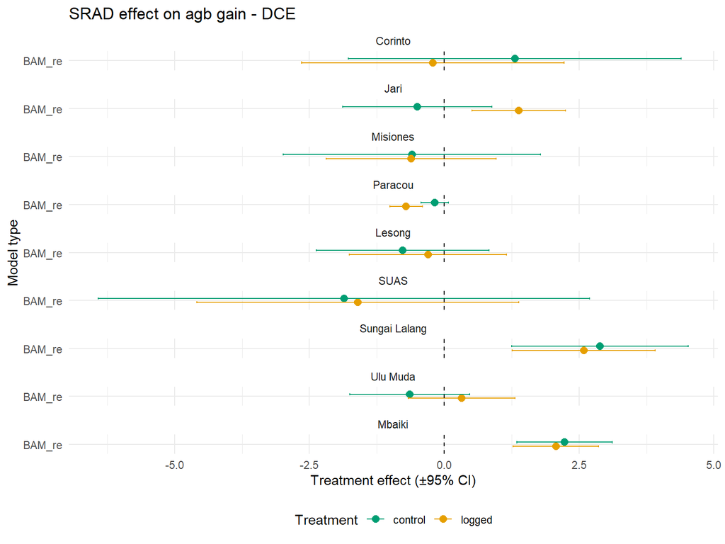

```r
final_plot_srad2 <- final_table_combined %>%
  filter(
    Term_type == "parametric",
    grepl("treatment", term)
  ) %>%
  mutate(
    Treatment = gsub("mean_z_srad:treatment", "", term)
  )

setDT(final_plot_srad2)


final_plot_srad2$Treatment <- factor(
  final_plot_srad2$Treatment,
  levels = rev(c("control","logged")),
  ordered = TRUE
)

final_plot_srad2$Model <- factor(
  final_plot_srad2$Model,
  levels = c("Corinto", "Jari", "Misiones", "Paracou",
             "Lesong", "SUAS", "Sungai Lalang",
             "Ulu Muda", "Mbaiki")
)

pd <- position_dodge(width = 0.5)

    p <- ggplot(
      final_plot_srad2,
      aes(
        x = estimate,
        y = Model_type,
        color = Treatment, group = Treatment
      )
    ) +
  geom_point(aes(color = Treatment, group = Treatment), position = position_dodge(0.5),size = 2.5) +
      geom_errorbarh(
        aes(
          xmin = estimate - 1.96 * std.error,
          xmax = estimate + 1.96 * std.error
        ),
        height = 0.25,
          position = pd
      ) +
      geom_vline(xintercept = 0, linetype = "dashed") +
        scale_color_manual(values = c("control" = "#009E73", "logged" = "#E69F00"),
  breaks = c("control", "logged")) +
      facet_wrap(~ Model, ncol = 1) +
      labs(
        x = "Treatment effect (±95% CI)",
        y = "Model type",
        title = paste(
          "SRAD effect on agb gain - DCE"
        )
      ) +
      theme_minimal()

p <- p +
  theme(
    legend.position = "bottom"
  )
    print(p)
```

#CWD - TCE and DCE (same because there are no mediators)

```r
#cor.test(merged$mean_z_cwd, merged$mean_z_vpd)#check if vpd is confounder


site_models2<- list()

table_results_combined <- list()

for (s in sites) {
  merged_site <- merged[site == s]

  # choose k based on unique years
    ny <- uniqueN(merged_site$interval_num)

  k_use <- fifelse(ny <= 20, 3,
          fifelse(ny <= 25, 5, 7))

  #cat("Site:", s, "- unique years:", uniqueN(merged_site$interval_num), "- k used:", k_use, "\n")


  AR <- ave(merged_site$interval_num, merged_site$subplot, FUN = function(x) x == min(x)) |> as.logical()

    # ---- 1) baseline model (NO AR) - used to estimate rho
  m0 <- bam(
    agb_gain ~
      s(interval_num, k = k_use) +
      s(treatment, bs = "re") +
      s(subplot, bs = "re") +
      s(interval_num, subplot, bs = "fs", k = k_use)+
          mean_z_cwd:treatment+mean_z_vpd+mean_z_srad+mean_z_tmax,
    data = merged_site,
    discrete = FALSE
  )

mf0 <- model.frame(m0)

res0 <- resid(m0, type = "response")

# Compute lag-1 autocorrelation for each subplot separately

acf_list <- lapply(split(res0, mf0$subplot), function(x) {
  if(length(x) < 3) return(NA_real_)
  acf(x, plot = FALSE)$acf[2]
})

# Pick the largest absolute lag-1 among all subplots for the site
# This ensures that rho0 captures the strongest temporal correlation present
rho0 <- max(abs(unlist(acf_list)), na.rm = TRUE)
rho0 <- max(min(rho0, 0.8), 0)

  #cat("  estimated rho:", round(rho0, 3), "\n")

    # fit BAM
  mod3 <- bam(
    agb_gain ~
      s(interval_num, k = k_use) +
      s(treatment, bs="re") +
      s(subplot, bs="re")+
      s(interval_num, subplot, bs="fs", k=k_use)+
          mean_z_cwd:treatment+mean_z_vpd+mean_z_srad+mean_z_tmax,
    data = merged_site,
    rho = rho0,
    AR.start = AR,
    discrete = FALSE
  )

  #

  #plot(mod3, select=1)

  res <- residuals(mod3, type="response")

mf <- model.frame(mod3)

acf_res <- tapply(
  res,
  mf$subplot,
  function(x) {
    if (length(x) < 3) return(NULL)
    acf(x, plot = FALSE)
  }
)
      site_models2[[s]]<- list(
      model = mod3,
      rho = rho0,
      residuals = res,
      acf = acf_res
    )

  param_tab3  <- broom::tidy(mod3, parametric = TRUE) %>% mutate(Term_type = "parametric")
  smooth_tab3 <- broom::tidy(mod3, parametric = FALSE) %>% mutate(Term_type = "smooth")
  tab_mod3    <- bind_rows(param_tab3, smooth_tab3) %>%
                    mutate(Model_type = "BAM_re",
                           Model = s)


  # ---- combine both models for this site ----
  table_results_combined[[s]] <- bind_rows(tab_mod3)
}

# combine all sites into one table
final_table_combined <- bind_rows(table_results_combined)

final_table_combined <- final_table_combined %>%
  filter(grepl("treatment", term))

res_plot2 <- rbindlist(
  lapply(names(site_models2), function(s) {
    df_site <- merged[site == s]

    # only rows used in BAM
    used <- !is.na(df_site$agb_gain)

    data.table(
      site = s,
      interval_num = df_site$interval_num[used],
      subplot = df_site$subplot[used],
      residual = site_models[[s]]$residuals
    )
  })
)
```

###plot per treatment

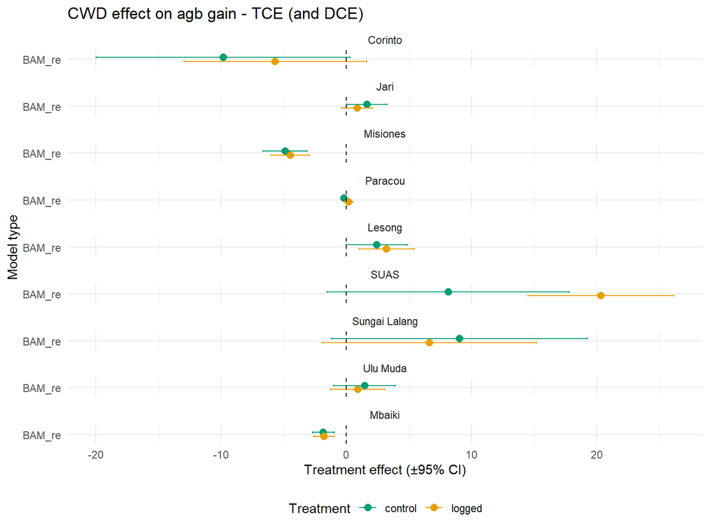

```r
final_plot_cwd <- final_table_combined %>%
  filter(
    Term_type == "parametric",
    grepl("treatment", term)
  ) %>%
  mutate(
    Treatment = gsub("mean_z_cwd:treatment", "", term)
  )

setDT(final_plot_cwd)


final_plot_cwd$Treatment <- factor(
  final_plot_cwd$Treatment,
  levels = rev(c("control","logged")),
  ordered = TRUE
)


final_plot_cwd$Model <- factor(
  final_plot_cwd$Model,
  levels = c("Corinto", "Jari", "Misiones", "Paracou",
             "Lesong", "SUAS", "Sungai Lalang",
             "Ulu Muda", "Mbaiki")
)


pd <- position_dodge(width = 0.5)

    p <- ggplot(
      final_plot_cwd,
      aes(
        x = estimate,
        y = Model_type,
        color = Treatment, group = Treatment
      )
    ) +
  geom_point(aes(color = Treatment, group = Treatment), position = position_dodge(0.5),size = 2.5) +
      geom_errorbarh(
        aes(
          xmin = estimate - 1.96 * std.error,
          xmax = estimate + 1.96 * std.error
        ),
        height = 0.25,
          position = pd
      ) +
      geom_vline(xintercept = 0, linetype = "dashed") +
        scale_color_manual(values = c("control" = "#009E73", "logged" = "#E69F00"),
  breaks = c("control", "logged")) +
      facet_wrap(~ Model, ncol = 1) +
      labs(
        x = "Treatment effect (±95% CI)",
        y = "Model type",
        title = paste(
          "CWD effect on agb gain - TCE (and DCE)"
        )
      ) +
      theme_minimal()

p <- p +
  theme(
    legend.position = "bottom"
  )
    print(p)
```

```r
clim_site_means <- list()

for (s in sites) {

   obs_site <- data[site == s]

  obs_site2 <- obs_site[rel_year >= 0]

  obs_site_wide <- dcast(
  obs_site2,
  treatment+site + subplot + plot+ year ~ variable,
  value.var = "value"
)


  ## ---- climate stack
  clim_all <- rbindlist(
    lapply(clim_by_site[[s]], function(x) x$climate[[1]]),
    idcol = "plot"
  )



  clim_all[, cwd := NA_real_]#pre-allocated

  clim_all[
  , wmy := month[which.max(ppt)],
  by = year]#wettest month per year


#function compute CWD
fcwd_et <- function(cwd, ppt, aet, wmy, month, min_aet = 40, throughfall = 1,
                    reset_wmy = TRUE, min_cwd = -1000) {
  # ppt: monthly precipitation
  # eat: evapotranspiration (actual or climatological)
  # wmy: wettest month of the year
  # min_et: minimum ET threshold to avoid unrealistically low ET
  # throughfall: fraction of ppt that contributes to water balance
  # reset_wmy: logical, reset CWD at wettest month
  # min_cwd: lower bound for cumulative deficit


  for (i in seq(2, length(ppt))) {           # loop from month 2 to end
    # accumulate CWD: previous month's deficit + current month's water balance
    cwd[i] <- min(0, cwd[i-1] + (throughfall*ppt[i]) - max(aet[i], min_aet, na.rm = T), na.rm = T)

    # reset CWD to zero if this is the wettest month
    if (reset_wmy==T) {
      cwd[i] <- ifelse(month[i] == wmy[i], 0, cwd[i])
    }

    # impose lower bound: deficit cannot exceed min_cwd
   cwd[i] <- ifelse(cwd[i] < -1000, -1000, cwd[i])  }

  return(cwd)                # return the full CWD vector
}
  setorder(clim_all, plot, year, month)

  clim_all[, cwd := fcwd_et(cwd, ppt, aet, wmy, month)]


  obs_site_wide <- obs_site_wide[order(subplot, year)]

obs_site_wide[, interval := .GRP, by = .(subplot, year)] #groups the data by subplot × year. it gives the group number in the order groups appear
obs_site_wide[, year_end := shift(year, type = "lead"), by = subplot] #for each subplot, year_end is the next census year
obs_site_wide[is.na(year_end), year_end := max(year), by=subplot] #The last year per subplot has no “next” year = NA. NA is replaced by max year
obs_site_wide[, interval := paste0(year, "_", year_end)]


intervals <- obs_site_wide[, .(subplot, plot, interval, year_start = year, year_end)]

# start and end year on climate data
clim_all[, `:=`(year_start = year, year_end = year)]

# 2️⃣ Set keys for foverlaps
setkey(intervals, plot, year_start, year_end)
setkey(clim_all, plot, year_start, year_end)

# 3️⃣ Perform the non-equi join
clim_all_interval <- foverlaps(
  clim_all,       # x #For each climate year, find the inventory interval it belongs to
  intervals,      # y
  by.x = c("plot", "year_start", "year_end"),
  by.y = c("plot", "year_start", "year_end"),
  type = "within",  # keep climate years inside interval
nomatch = 0L      # drop climate years outside any interval
  )



census_mean <- clim_all_interval[, .(
  mean_tmax   = mean(tmax,  na.rm = TRUE),

  mean_vpd   = mean(vpd,  na.rm = TRUE),

  mean_srad   = mean(srad,  na.rm = TRUE),

  mean_cwd    = mean(cwd,   na.rm = TRUE)
)]

  clim_site_means[[s]] <- census_mean

}


merged_census_mean <- rbindlist(clim_site_means, fill = TRUE, idcol = "site")

final_plot_tmax=merge(final_plot_tmax, merged_census_mean, by.x="Model", by.y="site")
final_plot_cwd$Treatment <- factor(
  final_plot_cwd$Treatment,
  levels = rev(c("control","logged")),
  ordered = TRUE
)

final_plot_vpd=merge(final_plot_vpd, merged_census_mean, by.x="Model", by.y="site")

final_plot_srad=merge(final_plot_srad, merged_census_mean, by.x="Model", by.y="site")


final_plot_cwd=merge(final_plot_cwd, merged_census_mean, by.x="Model", by.y="site")
```

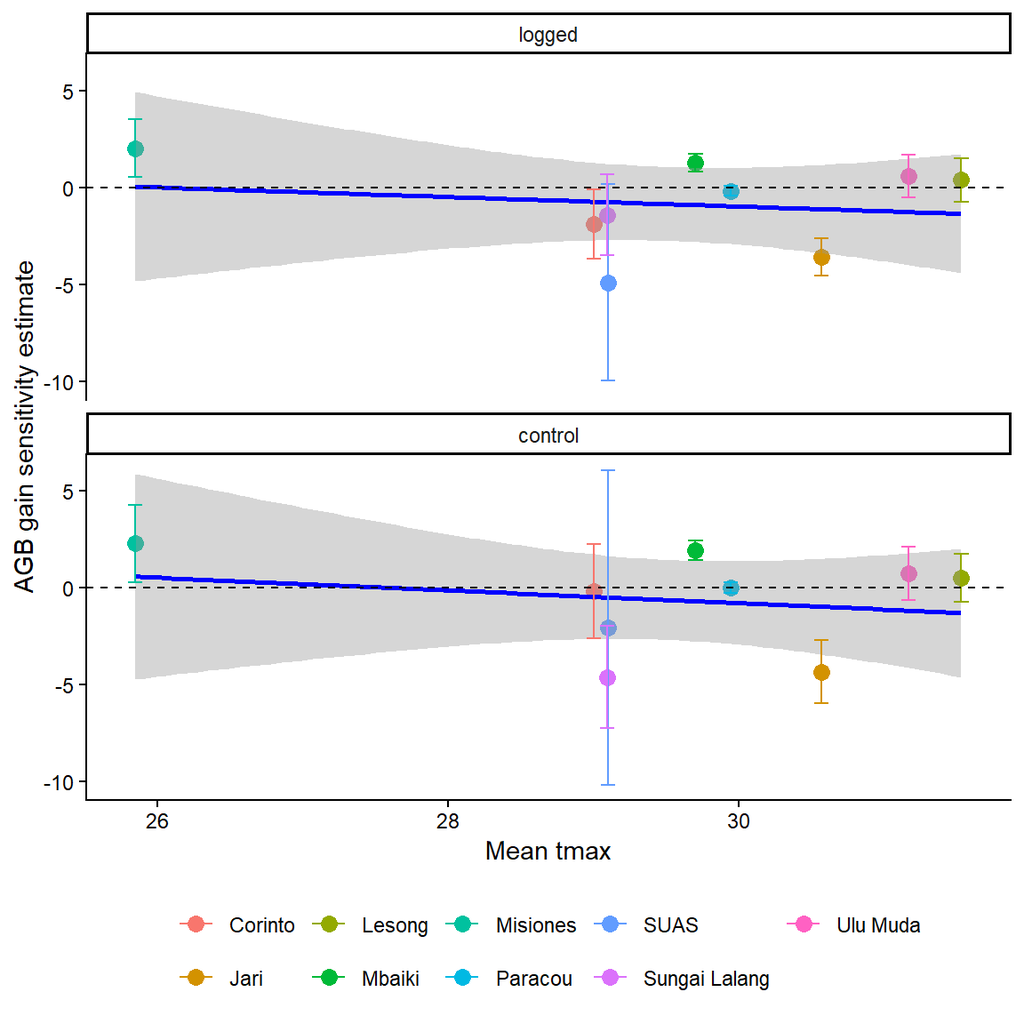

```r
ggplot(final_plot_tmax, aes(x = mean_tmax, y = estimate, color=Model)) +
  geom_point(size = 3) +
geom_smooth(method = "lm", se = TRUE, color = "blue") +
  geom_errorbar(aes(ymin = estimate - 1.96 * std.error,
                     ymax = estimate + 1.96 * std.error), width = 0.1) +
        geom_hline(yintercept = 0, linetype = "dashed") +
        facet_wrap(~ Treatment, ncol = 1) +
  theme_classic() +
  labs(x = "Mean tmax", y = "AGB gain sensitivity estimate",color = NULL) +
  theme(legend.position = "bottom")
```

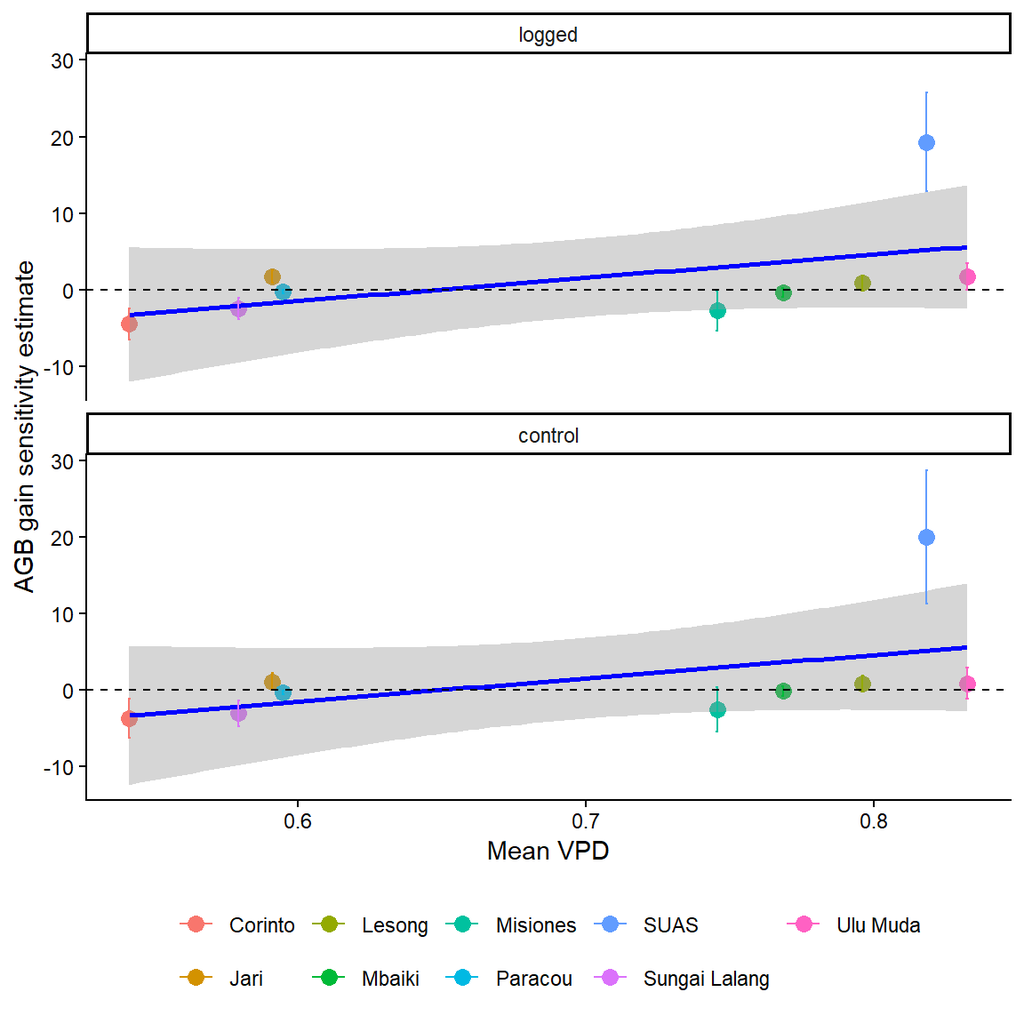

```r
ggplot(final_plot_vpd, aes(x = mean_vpd, y = estimate, color=Model)) +
  geom_point(size = 3) +
geom_smooth(method = "lm", se = TRUE, color = "blue") +
  geom_errorbar(aes(ymin = estimate - 1.96 * std.error,
                     ymax = estimate + 1.96 * std.error), width = 0.001) +
        geom_hline(yintercept = 0, linetype = "dashed") +
          facet_wrap(~ Treatment, ncol = 1) +
  theme_classic() +
  labs(x = "Mean VPD", y = "AGB gain sensitivity estimate",color = NULL) +
  theme(legend.position = "bottom")
```

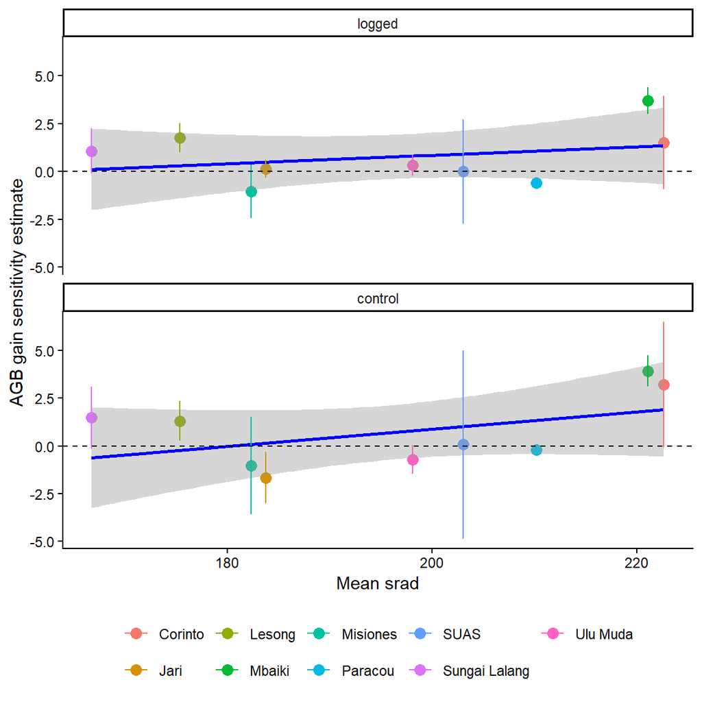

```r
ggplot(final_plot_srad, aes(x = mean_srad, y = estimate, color=Model)) +
  geom_point(size = 3) +
geom_smooth(method = "lm", se = TRUE, color = "blue") +
  geom_errorbar(aes(ymin = estimate - 1.96 * std.error,
                     ymax = estimate + 1.96 * std.error), width = 0.1) +
        geom_hline(yintercept = 0, linetype = "dashed") +
          facet_wrap(~ Treatment, ncol = 1) +
  theme_classic() +
  labs(x = "Mean srad", y = "AGB gain sensitivity estimate",color = NULL) +
  theme(legend.position = "bottom")
```

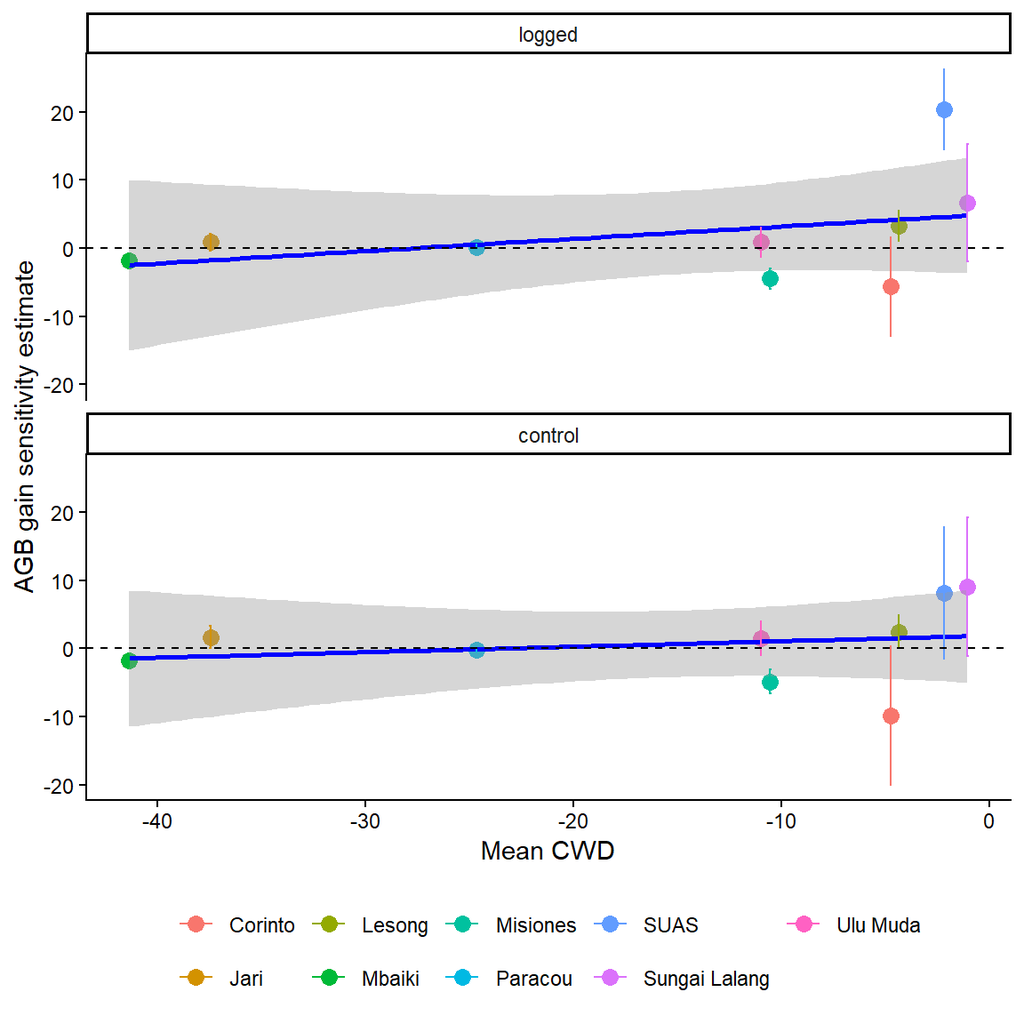

```r
ggplot(final_plot_cwd, aes(x = mean_cwd, y = estimate, color=Model)) +
  geom_point(size = 3) +
geom_smooth(method = "lm", se = TRUE, color = "blue") +
  geom_errorbar(aes(ymin = estimate - 1.96 * std.error,
                     ymax = estimate + 1.96 * std.error), width = 0.1) +
        geom_hline(yintercept = 0, linetype = "dashed") +
          facet_wrap(~ Treatment, ncol = 1) +
  theme_classic() +
  labs(x = "Mean CWD", y = "AGB gain sensitivity estimate",color = NULL) +
  theme(legend.position = "bottom")
```

#Interaction with CWM.

#vpd - TCE

```r
site_models2<- list()

table_results_combined <- list()

for (s in sites) {
  merged_site <- merged[site == s]

  # choose k based on unique years
    ny <- uniqueN(merged_site$interval_num)

  k_use <- fifelse(ny <= 20, 3,
          fifelse(ny <= 25, 5, 7))

  #cat("Site:", s, "- unique years:", uniqueN(merged_site$interval_num), "- k used:", k_use, "\n")


  AR <- ave(merged_site$interval_num, merged_site$subplot, FUN = function(x) x == min(x)) |> as.logical()

    # ---- 1) baseline model (NO AR) - used to estimate rho
  m0 <- bam(
    agb_gain ~
      s(interval_num, k = k_use) +
      s(treatment, bs = "re") +
      s(subplot, bs = "re") +
      s(interval_num, subplot, bs = "fs", k = k_use)+
          mean_z_vpd:LA_cwm_ba+mean_z_srad+mean_z_tmax,
    data = merged_site,
    discrete = FALSE
  )

mf0 <- model.frame(m0)

res0 <- resid(m0, type = "response")

# Compute lag-1 autocorrelation for each subplot separately

acf_list <- lapply(split(res0, mf0$subplot), function(x) {
  if(length(x) < 3) return(NA_real_)
  acf(x, plot = FALSE)$acf[2]
})

# Pick the largest absolute lag-1 among all subplots for the site
# This ensures that rho0 captures the strongest temporal correlation present
rho0 <- max(abs(unlist(acf_list)), na.rm = TRUE)
rho0 <- max(min(rho0, 0.8), 0)

  #cat("  estimated rho:", round(rho0, 3), "\n")

    # fit BAM
  mod3 <- bam(
    agb_gain ~
      s(interval_num, k = k_use) +
      s(treatment, bs="re") +
      s(subplot, bs="re")+
      s(interval_num, subplot, bs="fs", k=k_use)+
          mean_z_vpd:LA_cwm_ba+mean_z_srad+mean_z_tmax,
    data = merged_site,
    rho = rho0,
    AR.start = AR,
    discrete = FALSE
  )

  #

  #plot(mod3, select=1)

  res <- residuals(mod3, type="response")

mf <- model.frame(mod3)

acf_res <- tapply(
  res,
  mf$subplot,
  function(x) {
    if (length(x) < 3) return(NULL)
    acf(x, plot = FALSE)
  }
)
      site_models2[[s]]<- list(
      model = mod3,
      rho = rho0,
      residuals = res,
      acf = acf_res
    )

  param_tab3  <- broom::tidy(mod3, parametric = TRUE) %>% mutate(Term_type = "parametric")
  smooth_tab3 <- broom::tidy(mod3, parametric = FALSE) %>% mutate(Term_type = "smooth")
  tab_mod3    <- bind_rows(param_tab3, smooth_tab3) %>%
                    mutate(Model_type = "BAM_re",
                           Model = s)


  # ---- combine both models for this site ----
  table_results_combined[[s]] <- bind_rows(tab_mod3)
}

# combine all sites into one table
final_table_combined <- bind_rows(table_results_combined)

final_table_combined <- final_table_combined %>%
  filter(grepl("LA_cwm_ba", term))

res_plot2 <- rbindlist(
  lapply(names(site_models2), function(s) {
    df_site <- merged[site == s]

    # only rows used in BAM
    used <- !is.na(df_site$agb_gain)

    data.table(
      site = s,
      interval_num = df_site$interval_num[used],
      subplot = df_site$subplot[used],
      residual = site_models[[s]]$residuals
    )
  })
)
```

###plot per treatment

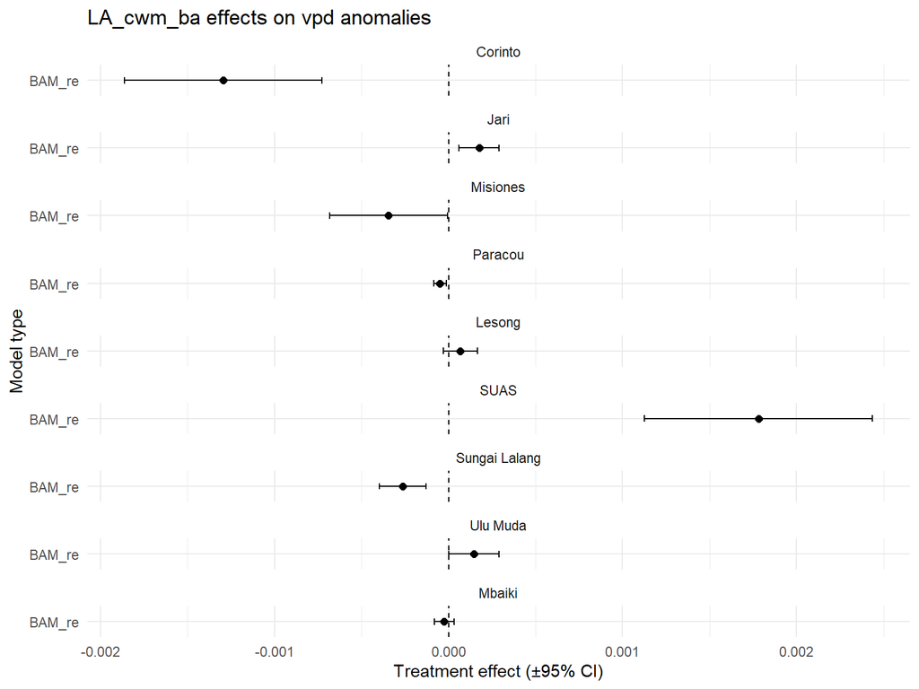

```r
final_plot_df <- final_table_combined %>%
  filter(
    Term_type == "parametric",
    grepl("LA_cwm_ba", term)
  ) %>%
  mutate(
    Treatment = gsub("mean_z_vpd:LA_cwm_ba", "", term)
  )


final_plot_df$Model <- factor(
  final_plot_df$Model,
  levels = c("Corinto", "Jari", "Misiones", "Paracou",
             "Lesong", "SUAS", "Sungai Lalang",
             "Ulu Muda", "Mbaiki")
)

    pd <- position_dodge(width = 1.0)

    p <- ggplot(
      final_plot_df,
      aes(
        x = estimate,
        y = Model_type
      )
    ) +
      geom_point(size = 2, position = pd) +
      geom_errorbarh(
        aes(
          xmin = estimate - 1.96 * std.error,
          xmax = estimate + 1.96 * std.error
        ),
        height = 0.25,
          position = pd
      ) +
      geom_vline(xintercept = 0, linetype = "dashed") +
      facet_wrap(~ Model, ncol = 1) +
      labs(
        x = "Treatment effect (±95% CI)",
        y = "Model type",
        title = paste(
          "LA_cwm_ba effects on vpd anomalies"
        )
      ) +
      theme_minimal()


    print(p)
```

#Does WD/LA/SLA/N affect the slope of vpd anomaly? Results?

#CWM LA effects. Highest CWM values always show stronger effect?